# Project: Flights Data Analysis

**#4: What is the percentage of flight operations that arrived late each weekend and weekday?**

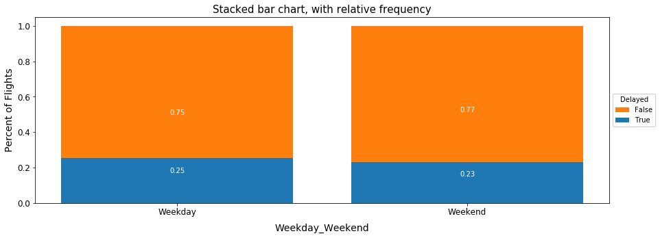

```python
# Let's plot a stacked bar chart, with relative frequency, for "Delayed" and "Weekday_Weekend"
cat1_order = df_clean.Weekday_Weekend.unique()
cat2_order = [True, False]
cat_var1 = 'Weekday_Weekend'
cat_var2 = 'Delayed'
func_stack_bar_per(df_clean, cat1_order, cat2_order, cat_var1, cat_var2, 'Percent of Flights')
```

```python
# Let's check the average delay per "Weekday_Weekend"
mean = df_clean.groupby('Weekday_Weekend')['Delayed'].mean().mean()
mean
```

```
0.24179840000126762
```

```python
# Let's get the maximum delay per "Weekday_Weekend"
maximum = df_clean.groupby('Weekday_Weekend')['Delayed'].mean().max()
maximum
```

```
0.25475167099080598
```

```python
# Let's check how more the maximum value is above the mean
(maximum - mean)/mean * 100
```

```
5.3570540539021136
```

In the stacked bar chart above we can see that, in our clean dataset, weekdays and weekends both have a similar percent of delayed flights. Weekdays have a slight higher percentage than the average (5% above).

**#5: What are the Top and Worst 5 Carriers based on their percent of late operations in 2007?**

```python
# Let's check the percent of late operation per carrier
df_clean.groupby('UniqueCarrier')['Delayed'].mean().sort_values()
```

```
UniqueCarrier
HA    0.063127
AQ    0.069456
WN    0.190535
9E    0.210607
DL    0.218661
F9    0.219844
FL    0.222170
OO    0.223729
YV    0.238555
XE    0.240485
CO    0.247254
AS    0.262094
MQ    0.276183
UA    0.277644
B6    0.282750
NW    0.288983
AA    0.290190
OH    0.292951
US    0.298669
EV    0.330157
Name: Delayed, dtype: float64
```

We see there is a tie with 22% in 4 airlines, so we decided to take a Top 4 of Carriers based on their percent of late operations (lowest values) in 2007, instead of Top 5.

```python
# Let's get the Top 4 of Carriers based on their percent of late operations in 2007 (lowest values)
table = df_clean.groupby('UniqueCarrier')['Delayed'].mean().sort_values().head(4)*100
```

```python
# Let's get the Average percent of late operations by carrier
mean = df_clean.groupby('UniqueCarrier')['Delayed'].mean().mean()*100
mean
```

```
23.720209666233213
```

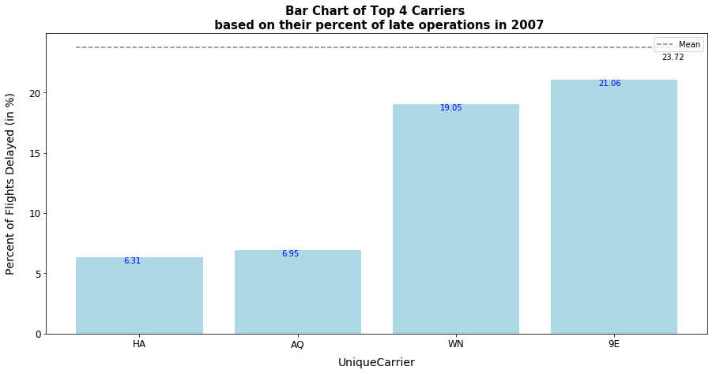

```python
# Let's plot a bar chart
x = table.index.values
y = pd.DataFrame(table.values, columns=['y'])
title = "Bar Chart of Top 4 Carriers \n based on their percent of late operations in 2007"
func_bar1(x, y['y'], title, "UniqueCarrier", "Percent of Flights Delayed (in %)" , 0.1, -0.5, mean, 'Mean')
```

```python
# Let's get the percent of late operations of "HA"
percent = y.y[0]
print(percent)

# Let's calculate how much lower is its percentage compared to the general mean
(percent - mean) / mean
```

```
6.31268436578
```

```
-0.73386894742468911
```

```python
# Let's check the value counts per Carrier
df_clean.UniqueCarrier.value_counts()
```

```
WN    1156958
AA     613836
OO     582871
MQ     516205
UA     477090
US     475583
DL     468323
XE     422305
NW     405872
CO     319138
YV     282585
EV     276617
FL     259869
9E     250186
OH     224471
B6     187116
AS     157123
F9      97219
HA      55935
AQ      45957
Name: UniqueCarrier, dtype: int64
```

We can see that, in our clean dataset, Hawaiian Airlines (HA) is the Carrier who had the lowest percent of late operations: 6.31%, which is 73% lower than the average percent of delay per carrier. However, when checking how many operations it had, it was one of the Bottom 2 of the lowest amount of flight operations. This pattern repeats with Aloha Airlines (AQ). Both airlines (Hawaiian Airlines and Aloha Airlines) have the fewest operations in our clean dataset and the lowest percent of late arrivals.

What is also surprising is that Southwest Airlines (WN) is in our Top 4 ranking (of lowest percent of late operations), having the highest amount of annual operations in our clean dataset. This, in contrast with the other 2 previous airlines, shows how a carrier can excel in the quality of service despite having a massive amount of services.

Since there are no ties in the higher values of percent of late operations by Carrier, let's get the Worst 5 of Carriers based on their percent of late operations (highest values) in 2007.

```python
# Let's get the Worst 5 of Carriers based on their percent of late operations in 2007 (highest values)
table = df_clean.groupby('UniqueCarrier')['Delayed'].mean().sort_values(ascending=False).head(5)*100
```

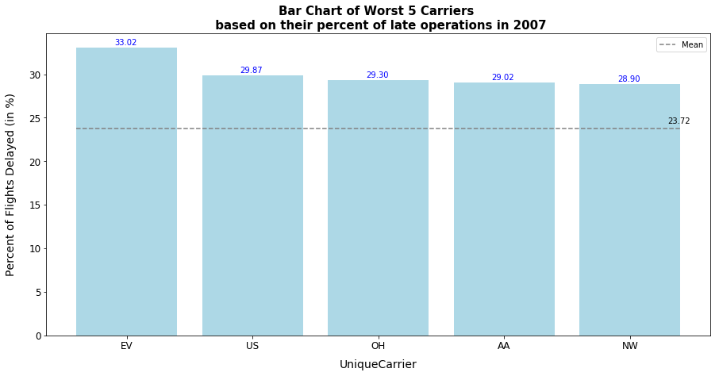

```python
# Let's plot a bar chart
x = table.index.values
y = pd.DataFrame(table.values, columns=['y'])
title = "Bar Chart of Worst 5 Carriers \n based on their percent of late operations in 2007"
func_bar1(x, y['y'], title, "UniqueCarrier", "Percent of Flights Delayed (in %)" , 0.1, 0.3, mean, 'Mean')
```

```python
# Let's get the percent of late operations of "EV"
percent = y.y[0]
print(percent)

# Let's calculate how much higher is its percentage compared to the general mean
(percent - mean) / mean * 100
```

```
33.0156859484
```

```
39.188002184654636
```

We can see that, in our clean dataset, Atlantic Southeast Airlines (EV) is the Carrier who had the highest percent of late operations: 33.02%, which is 39% higher than the average percent of delay per carrier.

The airlines in our Worst 5 ranking have a varied amount of annual operations, so there is no surprise in there.

**#6: What are the Top and Worst 10 Destination Airports based on their percent of late arrival operations?**

```python
# Let's check the percent of late operations per "Dest"
df_clean.groupby('Dest')['Delayed'].mean().sort_values()
```

```
Dest
MKC    0.000000
GLH    0.000000
ITO    0.052069
LIH    0.070389
KOA    0.084837
OGG    0.092542
HNL    0.097107
EAU    0.107692
PIH    0.108971
EKO    0.113712
PMD    0.123360
OXR    0.138163
SUN    0.140224
TWF    0.143128
CLD    0.151504
IYK    0.156550
LWS    0.159830
SGU    0.162334
SMX    0.163594
RDM    0.164463
HTS    0.167883
FLG    0.169623
SBA    0.169707
COD    0.170507
CPR    0.171916
STX    0.175476
SBP    0.175917
PLN    0.178357
BFL    0.180561
MRY    0.182965
         ...
ADK    0.340206
BTV    0.342656
APF    0.343866
JFK    0.347276
PFN    0.347425
BQK    0.349896
OAJ    0.350358
EYW    0.352262
```

[output cut: 8 more lines]

```
EWR    0.378470
LGA    0.380505
CSG    0.380987
VLD    0.384990
ACY    0.391241
TTN    0.404450
AGS    0.404687
MQT    0.414467
MEI    0.415902
GST    0.420455
ACK    0.439286
GNV    0.457004
HHH    0.476695
SOP    0.478495
Name: Delayed, Length: 304, dtype: float64
```

```python
# Let's get the Top 10 Destination Airports based on their percent of late arrival operations (lowest values)
table = df_clean.groupby('Dest')['Delayed'].mean().sort_values().head(10)*100
```

```python
# Let's get the Average percent of late operations by Destination Airport
mean = df_clean.groupby('Dest')['Delayed'].mean().mean()*100
mean
```

```
25.838297735940401
```

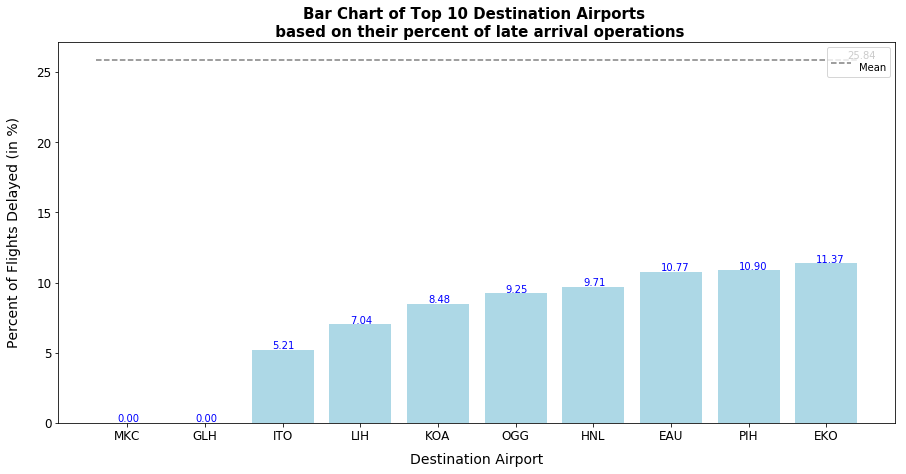

```python
# Let's plot a bar chart of Top 10 Destination Airports based on their percent of late arrival operations
x = table.index.values
y = pd.DataFrame(table.values, columns=['y'])
title = "Bar Chart of Top 10 Destination Airports \n based on their percent of late arrival operations"
func_bar1(x, y['y'], title, "Destination Airport", "Percent of Flights Delayed (in %)" , 0.13, 0.05, mean, '\nMean')
```

We can see that, in our clean dataset, Charles B. Wheeler Downtown Airport (MKC) and Mid-Delta Airport (GLH) did not have delayed flights, as destination airports, in 2007. This is interesting as the average arrival delay per destination airport is 25.84%.  
Let's look at their value counts.

```python
# Let's look at the value counts of "MKC" as destination airport
df_clean[df_clean['Dest'] == 'MKC'].shape[0]
```

```
1
```

```python
# Let's look at the value counts of "GLH" as destination airport
df_clean[df_clean['Dest'] == 'GLH'].shape[0]
```

```
2
```

So these two destinations had so few operations, it is not surprising their percent of flights delay is zero.

```python
# Let's check the destination airport with the lowest amount of operations
df_clean.Dest.value_counts().tail(10)
```

```
DLG    171
MTH    124
BJI    114
ADK     97
GST     88
EAU     65
ISO      7
PIR      3
GLH      2
MKC      1
Name: Dest, dtype: int64
```

Besides MKC and GLH, EAU (Chippewa Valley Regional Airport) is also an airport with the lowest amount of operations that is also in our Top 10 Destination Airports based on their percent of late arrival operations (lowest values). However, Chippewa Valley Regional Airport has 10.77% of delay flights.

```python
# Let's get the Worst 10 Destination Airports based on their percent of late arrival operations (highest values)
table = df_clean.groupby('Dest')['Delayed'].mean().sort_values(ascending=False).head(10)*100
```

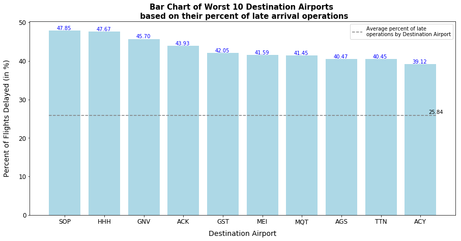

```python
# Let's plot a bar chart of Worst 10 Destination Airports based on their percent of late arrival operations
x = table.index.values
y = pd.DataFrame(table.values, columns=['y'])
title = "Bar Chart of Worst 10 Destination Airports \n based on their percent of late arrival operations"
func_bar1(x, y['y'], title, "Destination Airport", "Percent of Flights Delayed (in %)" , 0.2, 0.2, mean, 'Average percent of late\noperations by Destination Airport')
```

```python
# Let's get the percent of late operations of "SOP"
percent = y.y[0]
print(percent)

# Let's calculate how much higher is its percentage compared to the general mean
(percent - mean) / mean
```

```
47.8494623656
```

```
0.85188137603329961
```

```python
# Let's check the destination airport with the highest amount of operations (as destination)
df_clean.Dest.value_counts().head(10)
```

```
ATL    404970
ORD    357261
DFW    285765
DEN    236330
LAX    234050
PHX    207723
IAH    197088
LAS    181832
DTW    172679
MSP    151573
Name: Dest, dtype: int64
```

In the bar chart above we see that, in our clean dataset, Moore County Airport (SOP) is the airport with the worst percent of late arrival operations: 47.85%, 85% higher than the Average percent of late operations by Destination Airport.  
It is worth noting that none of the highest-amount of operations Airports (as destination) is in the Worst 10 ranking. However, Gustavus Airport (GST) is in the Worst 10 ranking of Destination Airports based on their percent of late arrival operations (highest values) despite its few operations as a destination airport.

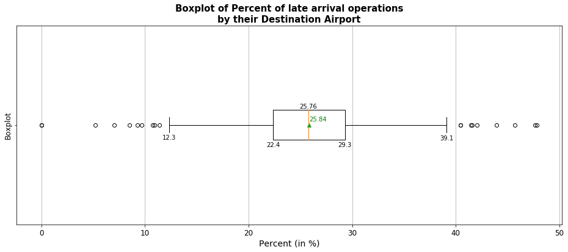

```python
# Let's check the Boxplot of Percent of late arrival operations by their Destination Airport
table = df_clean.groupby('Dest')['Delayed'].mean() * 100
func_box(table, 'Percent of late arrival operations\nby their Destination Airport', 'Percent (in %)', 2)
```

In our clean dataset, the majority of Destination Airports (between 25% and 75% percentile) had a delayed in their arrival operations between 22.4% and 29.3%.  
Since there are more outliers with high values rather than those with lower values, the mean (25.84%) is little bit higher than the median (25.76%).

**#7: What are the Top and Worst 10 Origin Airports based on their percent of flights that arrived late to their destinations?**

```python
# Let's check the percent of late operations per "Origin"
df_clean.groupby('Origin')['Delayed'].mean().sort_values()
```

```
Origin
GLH    0.000000
ITO    0.050414
PIH    0.059018
LIH    0.068109
WYS    0.072243
IYK    0.073326
OGG    0.086504
KOA    0.088977
TWF    0.089904
BPT    0.091168
EKO    0.091671
HNL    0.093163
OXR    0.098054
BLI    0.103270
SLE    0.104061
PLN    0.105263
CMX    0.114583
LWS    0.119829
SUN    0.120132
BTM    0.124372
ISO    0.125000
SGU    0.136124
ISP    0.140587
SBP    0.145694
CLD    0.145818
PSC    0.146369
BRO    0.149359
COD    0.150192
EAU    0.151515
FLG    0.152514
         ...
OME    0.305609
BTV    0.309489
FAY    0.310248
CLT    0.312274
ACY    0.313754
CSG    0.315282
SYR    0.316174
PSG    0.320644
```

[output cut: 8 more lines]

```
MEI    0.337423
HHH    0.338983
EYW    0.339130
JFK    0.358020
LWB    0.362162
GST    0.372093
DLG    0.374269
YKM    0.375921
AKN    0.424658
CEC    0.426854
ACK    0.494585
SOP    0.529730
PIR    0.750000
MKC    1.000000
Name: Delayed, Length: 304, dtype: float64
```

```python
# Let's get the Top 10 Origin Airports
# based on their percent of flights that arrived late to their destinations (lowest values)
table = df_clean.groupby('Origin')['Delayed'].mean().sort_values().head(10)*100
```

```python
# Let's get the Average percent of late operations by Origin Airport
mean = df_clean.groupby('Origin')['Delayed'].mean().mean()*100
mean
```

```
22.975815178333121
```

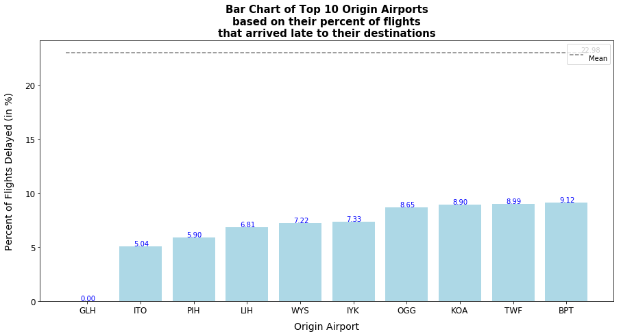

```python
# Let's plot a bar chart of
# Top 10 Origin Airports based on their percent of flights that arrived late to their destinations (lowest values)
x = table.index.values
y = pd.DataFrame(table.values, columns=['y'])
title = "Bar Chart of Top 10 Origin Airports\nbased on their percent of flights\nthat arrived late to their destinations"
func_bar1(x, y['y'], title, "Origin Airport", "Percent of Flights Delayed (in %)" , 0.13, 0.05, mean, '\nMean')
```

We can see that, in our clean dataset, Mid-Delta Airport (GLH), as origin airport, did not have flights arriving late to their destinations. This is interesting as the average arrival delay per origin airport is 22.98%. This is most likely because of few operations of GLH airport in our dataset.  
Let's look at their value counts.

```python
# Let's look at the value counts of "GLH" as origin airport
df_clean[df_clean['Origin'] == 'GLH'].shape[0]
```

```
2
```

So, as expected, Mid-Delta Airport (GLH) had so few operations, it is not surprising its percent of flights delay is zero.

```python
# Let's check the origin airport with the lowest amount of operations (as Origin)
df_clean.Origin.value_counts().tail(10)
```

```
DLG    171
MTH    126
BJI    114
ADK     89
GST     86
EAU     66
ISO      8
PIR      4
GLH      2
MKC      1
Name: Origin, dtype: int64
```

When checking the origin airports with the lowest amount of operations, we see that only GLH appears in the Top 10 Origin Airports based on their percent of flights that arrived late to their destinations (lowest values).

```python
# Let's get the Worst 10 Origin Airports
# based on their percent of flights that arrived late to their destinations (highest values)
table = df_clean.groupby('Origin')['Delayed'].mean().sort_values(ascending=False).head(10)*100
```

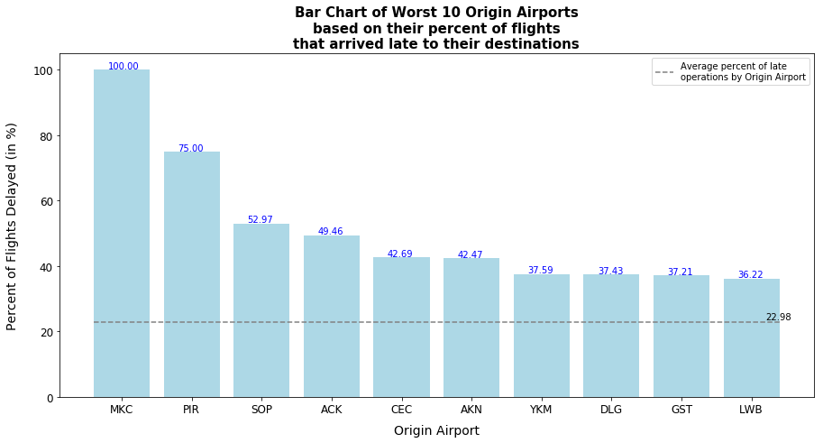

```python
# Let's plot a bar chart of
# Worst 10 Origin Airports based on their percent of flights that arrived late to their destinations
x = table.index.values
y = pd.DataFrame(table.values, columns=['y'])
title = "Bar Chart of Worst 10 Origin Airports\nbased on their percent of flights\nthat arrived late to their destinations"
func_bar1(x, y['y'], title, "Origin Airport", "Percent of Flights Delayed (in %)" , 0.2, 0.3, mean, 'Average percent of late\noperations by Origin Airport')
```

We can see that, in our clean dataset, Charles B. Wheeler Downtown Airport (MKC), as origin airport, had all of their flights arriving late to their destination. But, because of the previous value count, we noticed this is because its one single flight arrived late to its destination.  
What it is interesting is the fact that other three origin airports with the lowest amount of annual operation (PIR, GST, DLG) are also in this Worst 10 ranking of Origin Airports, based on their percent of flights that arrived late to their destinations (highest values). We would have expected to see airports with the highest amount of annual operation in this ranking. Let's see if that is true.

```python
# Let's check the origin airports with the highest amount of operations (as Origin)
df_clean.Origin.value_counts().head(10)
```

```
ATL    406136
ORD    358462
DFW    287372
DEN    236650
LAX    233939
PHX    208203
IAH    197869
LAS    181401
DTW    173020
MSP    151965
Name: Origin, dtype: int64
```

In fact, none of the Top 10 airports with the highest annual amount of operations (as origin) is in the Worst 10 ranking of Origin Airports based on their percent of flights that arrived late to their destinations (highest values).

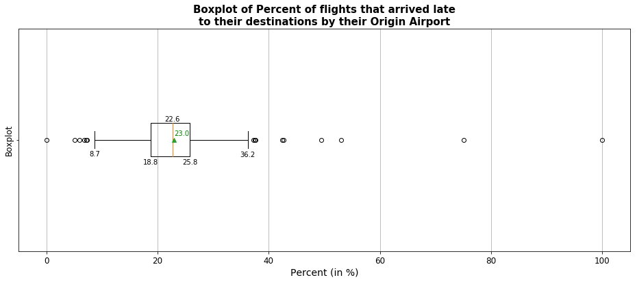

```python
# Let's check the Boxplot of percent of flights that arrived late to their destinations by their Origin Airport
table = df_clean.groupby('Origin')['Delayed'].mean() * 100
func_box(table, 'Percent of flights that arrived late\nto their destinations by their Origin Airport', 'Percent (in %)', 2)
```

**#8: What are the Flight Numbers with the highest percent of late operations?**

```python
# Let's get the percent of late operations by Flight Number
df_clean.groupby('FlightNum')['Delayed'].mean().sort_values(ascending=False).head(20)
```

```
FlightNum
9600    1.000000
7824    1.000000
9523    1.000000
9512    1.000000
9510    1.000000
3308    1.000000
9507    1.000000
7787    1.000000
3337    1.000000
9506    1.000000
9004    1.000000
7771    0.933333
7826    0.866667
7763    0.857143
7779    0.800000
7765    0.800000
6311    0.777778
666     0.750000
7822    0.733333
7764    0.723529
Name: Delayed, dtype: float64
```

We see that 11 Flight Numbers had all their operations late. So, let's do a Worst 11 Flight Numbers, with the highest percent of late operations.

```python
# Let's get the Worst 11 Flight Numbers with the highest percent of late operations
table = df_clean.groupby('FlightNum')['Delayed'].mean().sort_values(ascending=False).head(11)*100
table
```

```
FlightNum
9600    100.0
7824    100.0
9523    100.0
9512    100.0
9510    100.0
3308    100.0
9507    100.0
7787    100.0
3337    100.0
9506    100.0
9004    100.0
Name: Delayed, dtype: float64
```

```python
# Let's get the Average percent of late operations by Flight Number
mean = df_clean.groupby('FlightNum')['Delayed'].mean().mean()*100
mean
```

```
25.894912824206894
```

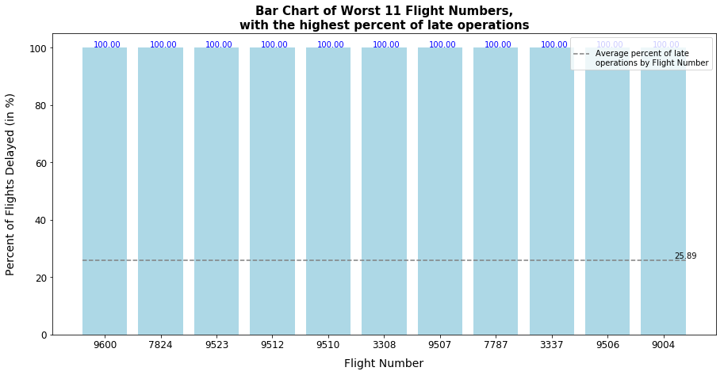

```python
# Let's plot a bar chart of
# Worst 11 Flight Numbers, with the highest percent of late operations
x = table.index.values
y = pd.DataFrame(table.values, columns=['y'])
title = "Bar Chart of Worst 11 Flight Numbers,\nwith the highest percent of late operations"
func_bar1(x, y['y'], title, "Flight Number", "Percent of Flights Delayed (in %)" , 0.2, 0.3, mean, '\nAverage percent of late\noperations by Flight Number')
```

```python
# Let's check the Flight Number with the lowest amount of operations
df_clean.FlightNum.value_counts().tail(44)
```

```
7807    2
9512    1
9504    1
9001    1
7598    1
3346    1
6993    1
9507    1
7016    1
9002    1
9506    1
6956    1
3496    1
8575    1
9004    1
```

[output cut: 30 more lines]

```python
# Let's check the Flight Number with the highest amount of operations
df_clean.FlightNum.value_counts().head(10)
```

```
16     5317
1      5198
67     4946
529    4916
500    4879
308    4778
399    4706
143    4698
43     4582
225    4544
Name: FlightNum, dtype: int64
```

We can see that, in our clean dataset, 11 Flight Numbers had all of their flights delayed. But, 8 of them only had one single flight in the entire dataset, so that explains the high value (100%) despite the Average percent of late operations by Flight Number being only 25.89%.  
Also, none of the Flight Numbers with the highest amount of operations were in the Worst 11 ranking of Flight Numbers, with the highest percent of late operations.

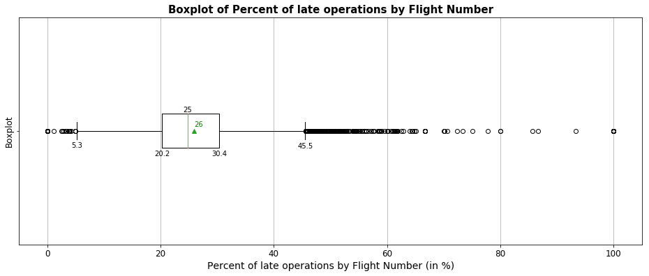

```python
# Let's check the Boxplot of Percent of late operations by Flight Number
table = df_clean.groupby('FlightNum')['Delayed'].mean().sort_values(ascending=False) * 100
func_box(table, 'Percent of late operations by Flight Number', 'Percent of late operations by Flight Number (in %)', 2)
```

In the boxplot above we can see that those 11 Flight Numbers of our Worst 11 ranking (with the highest percent of late operations) were outliers, following the IQR criteria. In our clean dataset, the majority of flight numbers (between 25% and 75% percentile) had a percent of late operations between 20.2% and 30.4%.  
Since there are more outliers with high values rather than those with lower values, the mean (26%) is higher than the median (25%). We should take this into consideration when deciding to use median or mean for our further analysis.

**#9: What are the Worst Routes (origin - destination) based on their highest percent of late operations?**

```python
# Let's get the percent of late operations by Route
df_clean.groupby('Route')['Delayed'].mean().sort_values(ascending=False).head(90)
```

```
Route
GRR - MKE    1.000000
AVP - JFK    1.000000
AVP - LGA    1.000000
SAV - MCO    1.000000
PFN - TLH    1.000000
AVP - PHL    1.000000
AZO - MKE    1.000000
BDL - BOS    1.000000
ONT - IAD    1.000000
OMA - MCI    1.000000
MHT - BOS    1.000000
GSP - RSW    1.000000
GSO - RDU    1.000000
CRW - ROA    1.000000
BHM - AUS    1.000000
CRW - RDU    1.000000
GSO - MSY    1.000000
FAT - BOI    1.000000
SLC - SDF    1.000000
CVG - SMF    1.000000
ELP - MFE    1.000000
PLN - DCA    1.000000
JFK - SAV    1.000000
SAV - JAX    1.000000
DCA - PLN    1.000000
SYR - HPN    1.000000
AVP - BUF    1.000000
EWR - JFK    1.000000
MDT - JFK    1.000000
DAB - ORD    1.000000
               ...
SRQ - MIA    1.000000
BWI - ABE    1.000000
BWI - AVP    1.000000
GSO - BNA    1.000000
JFK - LGA    1.000000
SDF - JFK    1.000000
BWI - LGA    1.000000
ORD - ROW    1.000000
```

[output cut: 8 more lines]

```
ABE - JFK    1.000000
RSW - MIA    1.000000
TYS - MCI    1.000000
GPT - MSY    1.000000
PIT - PVD    1.000000
MKC - MKE    1.000000
ABE - LGA    1.000000
LGA - DAB    0.900000
JFK - BGM    0.882353
ORD - DAB    0.857143
HDN - LGA    0.857143
MKE - MQT    0.800000
DAB - LGA    0.777778
EWR - MTJ    0.761905
Name: Delayed, Length: 90, dtype: float64
```

We see that 83 Routes had all their operations late. So, instead of doing a Worst 10 Routes ranking, let's analyze if those values are outliers.

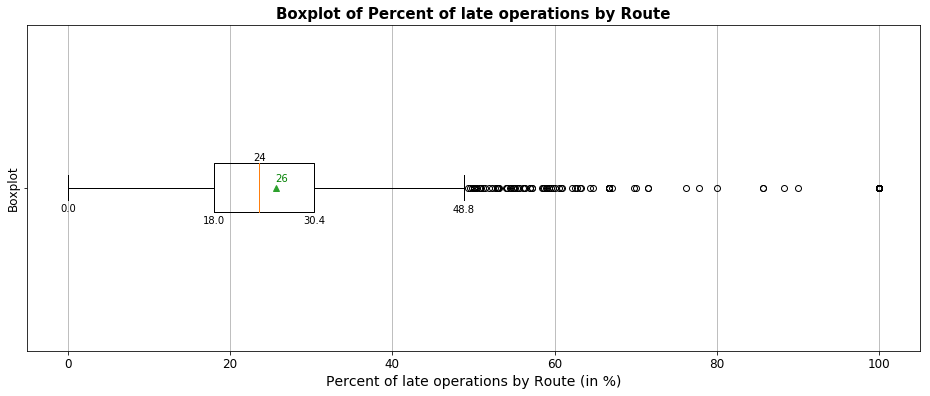

```python
# Let's check the Boxplot of Percent of late operations by Route
table = df_clean.groupby('Route')['Delayed'].mean().sort_values(ascending=False) * 100
func_box(table, 'Percent of late operations by Route', 'Percent of late operations by Route (in %)', 2)
```

In the boxplot above we can see that those 83 Routes, with all of their operations delayed, were indeed outliers according to the IQR criteria. In our clean dataset, the majority of Routes (between 25% and 75% percentile) had a percent of late operations between 18% and 30.4%.  
Since there are a lot of outliers with high values, the mean (26%) is higher than the median (24%). We should take this into consideration when deciding to use median or mean for our further analysis.

**#10: What is the distribution of Delayed flight vs Distance between airports?**

```python
# Let's define a function for a violinplot and a boxplot
def func_violin_box(df, cat_var, num_var):
    # upper plot: violin plot
    plt.figure(figsize = [16, 5])
    plt.subplot(2, 1, 1)
    ax1 = sns.violinplot(data = df, x = num_var, y = cat_var, orient='h', inner = None);

    # lower plot: box plot
    plt.subplot(2, 1, 2)
    sns.boxplot(data = df, x = num_var, y = cat_var, orient='h')
    plt.xlim(ax1.get_xlim());
```

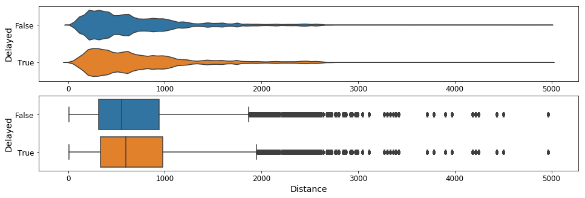

```python
# Let's plot a violinplot and a boxplot of 'Delayed' and 'Distance' columns
func_violin_box(df_clean, 'Delayed', 'Distance')
```

In the violinplot above, we can see that the distribution of Distance is pretty similar whether a flight was delayed or not. In the boxplot above, we can see that there a many outliers with high values in Distance for both, delayed and not delayed flights. However, we see a slight higher median of Distance for delayed flights, compared to flights who were not delayed.  
Let's repeat the same procedure but with a log-scale on distance as we previously saw that distance followed a somewhat log-normal distribution.

```python
# Let's define a function for a violinplot and a boxplot with log-scale in x axis
def func_violin_box_log(df, cat_var, num_var):
    # upper plot: violin plot
    plt.figure(figsize = [16, 5])
    plt.subplot(2, 1, 1)
    ax1 = sns.violinplot(data = df, x = num_var, y = cat_var, orient='h', inner = None)
    plt.xscale('log');

    # lower plot: box plot
    plt.subplot(2, 1, 2)
    sns.boxplot(data = df, x = num_var, y = cat_var, orient='h')
    plt.xscale('log')
    plt.xlim(ax1.get_xlim())
    plt.xlabel('Log10 of ' + num_var);
```

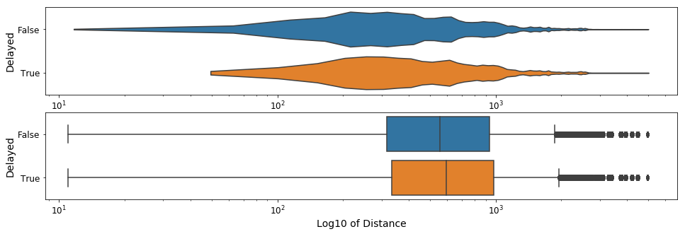

```python
# Let's plot a violinplot and a boxplot of 'Delayed' and log10 of 'Distance'
func_violin_box_log(df_clean, 'Delayed', 'Distance')
```

We can see that after a log transformation in Distance, the distribution for both delayed and not delayed flights becomes less right skewed. However, there are still a lot of high-values in both.

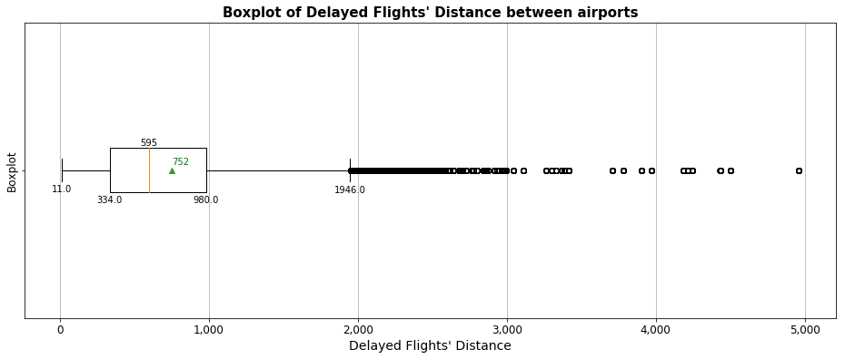

```python
# Let's see a boxplot of Delayed Flights' Distance in more detail (with natural units)
table = df_clean[df_clean['Delayed'] == True].Distance
func_box(table, 'Delayed Flights\' Distance between airports', 'Delayed Flights\' Distance', 2)
```

We can see that the majority of Delayed Flights (between 25% and 75%) had a Distance between 334 and 980 miles from origin to destination.  
Also, because of the high-values outliers, the mean (752 miles) is greater than the median (595 miles). This is something to consider for further analysis.

**#11: What is the distribution of Delayed flight vs Scheduled Elapsed Time?**

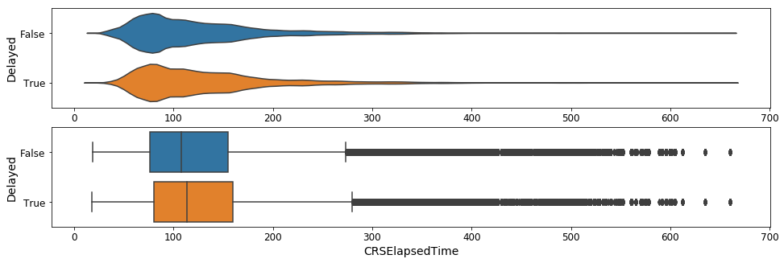

```python
# Let's plot a violinplot and a boxplot of 'Delayed' and 'CRSElapsedTime' columns
func_violin_box(df_clean, 'Delayed', 'CRSElapsedTime')
```

In the violinplot above, we can see that the distribution of Scheduled Elapsed Time is pretty similar whether a flight was delayed or not. In the boxplot above, we can see that there a many outliers with high values in Scheduled Elapsed Time for both, delayed and not delayed flights. However, we see a slight higher median of Scheduled Elapsed Time for delayed flights, compared to flights who were not delayed.  
Let's repeat the same procedure but with a log-scale on Scheduled Elapsed Time as we previously saw that Scheduled Elapsed Time followed a somewhat log-normal distribution.

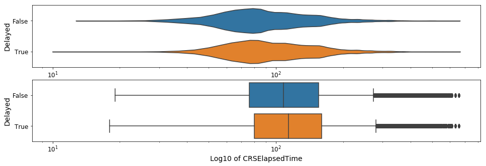

```python
# Let's plot a violinplot and a boxplot of 'Delayed' and log10 of 'CRSElapsedTime'
func_violin_box_log(df_clean, 'Delayed', 'CRSElapsedTime')
```

We can see that after a log transformation in Scheduled Elapsed Time, the distribution for both delayed and not delayed flights becomes less right skewed. However, there are still a lot of high-values in both.

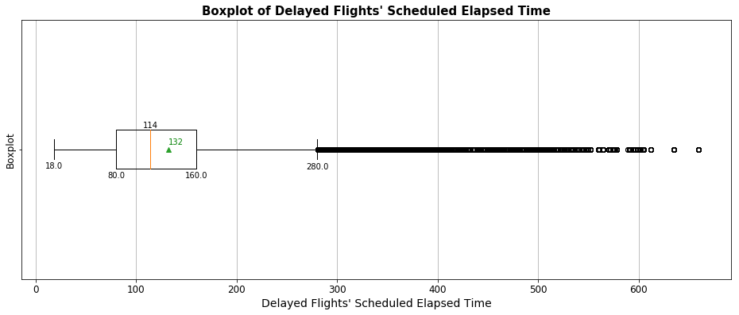

```python
# Let's see a boxplot of Delayed Flights' Scheduled Elapsed Time in more detail (with natural units)
table = df_clean[df_clean['Delayed'] == True].CRSElapsedTime
func_box(table, 'Delayed Flights\' Scheduled Elapsed Time', 'Delayed Flights\' Scheduled Elapsed Time', 2)
```

We can see that the majority of Delayed Flights (between 25% and 75%) had a Scheduled Elapsed Time between 80 and 160 minutes.  
Also, because of the high-values outliers, the mean (132 minutes) is greater than the median (114 minutes). This is something to consider for further analysis.

**#12: What is the distribution of flights per day of each month?**

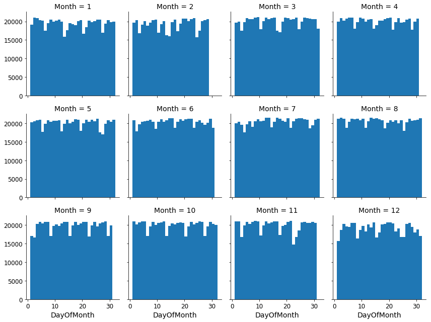

```python
# Let's plot a histogram of amount of flights per day facetted by month
bins = np.arange(1,31+2,1)
g = sns.FacetGrid(data = df_clean, col = 'Month', col_wrap = 4)
g.map(plt.hist, "DayOfMonth", bins=bins);
```

In the facetted histogram above we see that there is no clear pattern in the amount of flights per day of month among all months. However, this analysis could be expanded by adding a variable of weekday and weekend in the multivariate analysis.

### Let's talk about some of the relationships we observed in this part of the investigation. How did the feature of interest vary with other features in the dataset?

- Even though the percentage of delays per month follows a somewhat uniform distribution, there was a notable increment in the percentage of delayed flights during December 2007.
- Even though the percentage of delays per day of week follows a somewhat uniform distribution, Friday had the highest percent of the week.
- We also noticed a spike in the percent of delays per hour between 9 PM and 0 AM (inclusive), and a notable reduction in the percent of delays at 7 AM.
- We also noticed how the amount of flights of a Carrier, Origin and Destination Airport is related to its delay in flights. For example:
  - Hawaiian Airlines and Aloha Airlines have the fewest operations in our clean dataset and the lowest percent of late arrivals.
  - Charles B. Wheeler Downtown Airport (MKC) and Mid-Delta Airport (GLH), as destination airports, did not have delayed flights in 2007 but their flights operations as destination were less than 3.
  - Mid-Delta Airport (GLH), as origin airport, did not have flights arriving late to their destinations, but its flight operations as origin was less than 3.

### Were there any interesting relationships between the other features (not the main feature of interest)?

- There is no clear pattern in the amount of flights per day of month among all months. However, this analysis could be expanded by adding a variable of weekday and weekend in the multivariate analysis.

### Multivariate Exploration

**#1: What is the distribution of flight operations that arrived late each day of each month? Is there any pattern?**

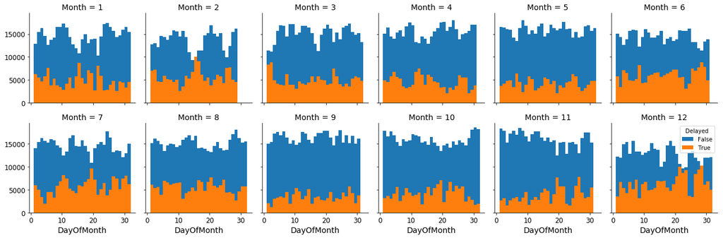

```python
# Let's plot the amount of flight operations that arrived late and not arrived late each day of each month
bins = np.arange(1,31+2,1)
g = sns.FacetGrid(data = df_clean, col = 'Month', col_wrap = 6, hue = 'Delayed')
g.map(plt.hist, "DayOfMonth", bins=bins)
plt.legend(title = 'Delayed');
```

In the facetted histogram above we see that, in our clean dataset, the amount of delayed flights per day during September 2007 is the lowest among all the months.

We also notice that the amount of flights that arrived late is always lower than the amount of flights that did not arrive late everyday of every month, with the exception of certain days in February and December. Further investigation should be performed those days to figure out what happened.

```python
# Let's get the amount of delayed and not delayed flights per day of month per month
table = df_clean.groupby(['Month', 'DayOfMonth'])['Delayed'].value_counts().unstack(fill_value=0)
table
```

| Month | Delayed DayOfMonth | False | True |
| --- | --- | --- | --- |
| 1 | 1 | 12892 | 6265 |
|  | 2 | 15441 | 5529 |
|  | 3 | 16250 | 4615 |
|  | 4 | 14580 | 5813 |
|  | 5 | 12627 | 7646 |
|  | 6 | 13739 | 3808 |
|  | 7 | 14261 | 5278 |
|  | 8 | 16584 | 3857 |
|  | 9 | 16506 | 3403 |
|  | 10 | 17316 | 2873 |
|  | 11 | 16420 | 4135 |
|  | 12 | 14378 | 5552 |
|  | 13 | 12719 | 3167 |
|  | 14 | 11900 | 5761 |
|  | 15 | 10837 | 8748 |
|  | 16 | 13825 | 5397 |
|  | 17 | 14912 | 4120 |
|  | 18 | 12960 | 7140 |
|  | 19 | 13839 | 6492 |
|  | 20 | 14022 | 2735 |
|  | 21 | 10316 | 8088 |
|  | 22 | 14391 | 5897 |
|  | 23 | 17189 | 2686 |
|  | 24 | 17335 | 2813 |
|  | 25 | 16577 | 3960 |
|  | 26 | 15617 | 4835 |
|  | 27 | 14374 | 2635 |
|  | 28 | 14741 | 4628 |
|  | 29 | 15963 | 4444 |
|  | 30 | 16512 | 3333 |
| ... | ... | ... | ... |
| 12 | 2 | 12015 | 6716 |
|  | 3 | 14892 | 5401 |
|  | 4 | 15382 | 4276 |
|  | 5 | 12860 | 6662 |
|  | 6 | 15586 | 5070 |
|  | 7 | 13306 | 7230 |
|  | 8 | 13278 | 3151 |
|  | 9 | 12509 | 6240 |
|  | 10 | 13115 | 6686 |
|  | 11 | 13374 | 4918 |
|  | 12 | 15166 | 5027 |
|  | 13 | 13950 | 5372 |
|  | 14 | 13709 | 6965 |
|  | 15 | 9957 | 6764 |
|  | 16 | 11080 | 6907 |
|  | 17 | 14640 | 5525 |
|  | 18 | 15660 | 4708 |
|  | 19 | 14555 | 6212 |
|  | 20 | 12865 | 7879 |
|  | 21 | 10561 | 9961 |
|  | 22 | 9613 | 8638 |
|  | 23 | 9876 | 9238 |
|  | 24 | 13096 | 3698 |
|  | 25 | 13405 | 3389 |
|  | 26 | 11962 | 8388 |
|  | 27 | 11214 | 9333 |
|  | 28 | 9297 | 10221 |
|  | 29 | 11906 | 6081 |
|  | 30 | 12003 | 6839 |
|  | 31 | 12028 | 5042 |

365 rows × 2 columns

```python
# Let's get the percent of delayed and not delayed flights per day of month per month
table.mean()
```

```
Delayed
False    14991.632877
True      4940.583562
dtype: float64
```

```python
# Let's check the difference in percentages between the delayed and not delayed flights per day of month per month
( table.mean().min() - table.mean().max() ) / table.mean().max() * 100
```

```
-67.04439334744896
```

In our clean dataset, on average, 4,940 flights arrived late per day of each month, which is 67% lower than the average amount of flights that didn't arrive late per day of each month (14,991 flights).

```python
# Let's get the percent of delayed flights per "DayOfMonth" per "Month"
table = df_clean.groupby(['Month', 'DayOfMonth'])['Delayed'].mean().unstack(fill_value=0)
table
```

| DayOfMonth Month | 1 | 2 | 3 | 4 | 5 | 6 | 7 | 8 | 9 | 10 | 11 | 12 | 13 | 14 | ... | 18 | 19 | 20 | 21 | 22 | 23 | 24 | 25 | 26 | 27 | 28 | 29 | 30 | 31 |
| --- | --- | --- | --- | --- | --- | --- | --- | --- | --- | --- | --- | --- | --- | --- | --- | --- | --- | --- | --- | --- | --- | --- | --- | --- | --- | --- | --- | --- | --- |
| 1 | 0.327035 | 0.263662 | 0.221184 | 0.285049 | 0.377152 | 0.217017 | 0.270126 | 0.188689 | 0.170928 | 0.142305 | 0.201168 | 0.278575 | 0.199358 | 0.326199 | ... | 0.355224 | 0.319315 | 0.163215 | 0.439470 | 0.290664 | 0.135145 | 0.139617 | 0.192823 | 0.236407 | 0.154918 | 0.238939 | 0.217768 | 0.167952 | 0.225583 |
| 2 | 0.352439 | 0.358642 | 0.275146 | 0.236326 | 0.289845 | 0.272612 | 0.256425 | 0.223145 | 0.245535 | 0.149788 | 0.184932 | 0.290470 | 0.324620 | 0.419792 | ... | 0.244926 | 0.268698 | 0.184533 | 0.249826 | 0.298862 | 0.274100 | 0.274577 | 0.436278 | 0.385267 | 0.244623 | 0.218449 | 0.000000 | 0.000000 | 0.000000 |
| 3 | 0.422234 | 0.439930 | 0.280080 | 0.210069 | 0.188507 | 0.186791 | 0.304249 | 0.186553 | 0.187828 | 0.173294 | 0.235940 | 0.200667 | 0.187893 | 0.212274 | ... | 0.254570 | 0.235325 | 0.186118 | 0.206898 | 0.362582 | 0.272467 | 0.225860 | 0.180306 | 0.200772 | 0.169170 | 0.253161 | 0.281303 | 0.264298 | 0.267501 |
| 4 | 0.247027 | 0.215577 | 0.284918 | 0.325597 | 0.268888 | 0.250951 | 0.195682 | 0.160022 | 0.165276 | 0.188026 | 0.336376 | 0.367149 | 0.299378 | 0.220888 | ... | 0.211790 | 0.161340 | 0.161892 | 0.120186 | 0.168464 | 0.137018 | 0.186171 | 0.305660 | 0.270079 | 0.269220 | 0.115785 | 0.143648 | 0.184734 | 0.000000 |
| 5 | 0.184109 | 0.203108 | 0.230022 | 0.237638 | 0.195476 | 0.320273 | 0.217364 | 0.117414 | 0.190665 | 0.278057 | 0.244857 | 0.154441 | 0.159276 | 0.175800 | ... | 0.226806 | 0.119831 | 0.189188 | 0.158234 | 0.214027 | 0.225180 | 0.307689 | 0.271357 | 0.193290 | 0.155557 | 0.160188 | 0.188921 | 0.231964 | 0.225937 |
| 6 | 0.276077 | 0.195997 | 0.360081 | 0.320631 | 0.238900 | 0.233740 | 0.245246 | 0.401536 | 0.230264 | 0.217970 | 0.277142 | 0.301372 | 0.315668 | 0.312728 | ... | 0.321011 | 0.349891 | 0.344947 | 0.258172 | 0.265934 | 0.166065 | 0.204994 | 0.362918 | 0.344497 | 0.393556 | 0.436859 | 0.367805 | 0.263250 | 0.000000 |
| 7 | 0.298051 | 0.246650 | 0.174471 | 0.111515 | 0.228284 | 0.220979 | 0.172319 | 0.283734 | 0.325385 | 0.395593 | 0.359488 | 0.246134 | 0.219477 | 0.228408 | ... | 0.355777 | 0.471233 | 0.339933 | 0.207865 | 0.249720 | 0.303932 | 0.173765 | 0.234480 | 0.375402 | 0.355910 | 0.276577 | 0.379621 | 0.382539 | 0.294561 |
| 8 | 0.287814 | 0.247517 | 0.264732 | 0.206738 | 0.338359 | 0.311817 | 0.287774 | 0.298673 | 0.312626 | 0.307917 | 0.159796 | 0.206610 | 0.214942 | 0.257751 | ... | 0.254175 | 0.333168 | 0.366091 | 0.289413 | 0.260763 | 0.297520 | 0.347755 | 0.241314 | 0.219451 | 0.194069 | 0.128440 | 0.220121 | 0.272381 | 0.271003 |
| 9 | 0.119796 | 0.073627 | 0.149887 | 0.156509 | 0.172956 | 0.155129 | 0.216544 | 0.114987 | 0.204503 | 0.267228 | 0.230874 | 0.142515 | 0.177023 | 0.243034 | ... | 0.137888 | 0.129067 | 0.148115 | 0.216553 | 0.139609 | 0.159498 | 0.141610 | 0.222375 | 0.174548 | 0.272876 | 0.200648 | 0.117661 | 0.190589 | 0.000000 |
| 10 | 0.148286 | 0.179558 | 0.144333 | 0.197347 | 0.267663 | 0.147185 | 0.189329 | 0.256904 | 0.215614 | 0.174808 | 0.188835 | 0.210311 | 0.108366 | 0.214431 | ... | 0.300380 | 0.344890 | 0.138349 | 0.239209 | 0.320585 | 0.229361 | 0.284443 | 0.249440 | 0.271189 | 0.142522 | 0.176339 | 0.132472 | 0.085745 | 0.095087 |
| 11 | 0.127041 | 0.148776 | 0.095241 | 0.135770 | 0.151414 | 0.168943 | 0.118099 | 0.154536 | 0.211856 | 0.096463 | 0.140715 | 0.159560 | 0.137552 | 0.209612 | ... | 0.204716 | 0.380701 | 0.272254 | 0.272852 | 0.134932 | 0.092042 | 0.167720 | 0.281072 | 0.376862 | 0.214867 | 0.152034 | 0.162763 | 0.263257 | 0.000000 |
| 12 | 0.223366 | 0.358550 | 0.266151 | 0.217520 | 0.341256 | 0.245449 | 0.352065 | 0.191795 | 0.332818 | 0.337660 | 0.268861 | 0.248948 | 0.278025 | 0.336897 | ... | 0.231147 | 0.299128 | 0.379821 | 0.485382 | 0.473289 | 0.483311 | 0.220198 | 0.201798 | 0.412187 | 0.454227 | 0.523670 | 0.338078 | 0.362966 | 0.295372 |

12 rows × 31 columns

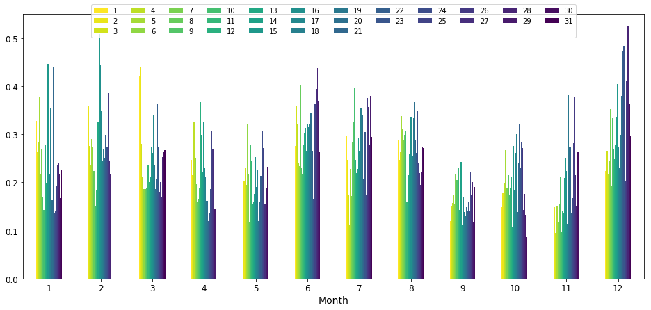

```python
# Let's plot a facetted bar chart to check the percent of delayed flights per "DayOfMonth" per "Month"
df2 = pd.DataFrame(table)
ax = df2.plot.bar(figsize=[16,7], colormap='viridis_r')
ax.legend(loc='upper center', bbox_to_anchor=(0.5, 1.05), ncol=12,
          fancybox=True, shadow=False)
plt.xticks(rotation=0);
```

In the facetted bar chart above we can see that, in our clean dataset, on average the percentage of delayed flights per day hits its lowest on September.

**#2: What is the distribution of flight operations that arrived late each day of week of each month? Is there any pattern?**

```python
# Let's first get a table of amount of flights per day of week of each month
table = df_clean.groupby(['Month', 'DayOfWeek']).size().unstack(fill_value=0)
table
```

| DayOfWeek Month | Monday | Tuesday | Wednesday | Thursday | Friday | Saturday | Sunday |
| --- | --- | --- | --- | --- | --- | --- | --- |
| 1 | 99878 | 99821 | 100138 | 81585 | 80986 | 67199 | 74973 |
| 2 | 81068 | 76352 | 76520 | 80471 | 82227 | 66929 | 75311 |
| 3 | 83885 | 83037 | 82690 | 103009 | 100299 | 88384 | 79753 |
| 4 | 103867 | 80920 | 81192 | 82841 | 83362 | 71606 | 98529 |
| 5 | 82634 | 101918 | 102888 | 104055 | 83966 | 71110 | 76755 |
| 6 | 83364 | 81785 | 82247 | 83667 | 105130 | 92731 | 80914 |
| 7 | 105132 | 104055 | 80321 | 82834 | 84375 | 75246 | 100923 |
| 8 | 84764 | 83505 | 105411 | 104341 | 105338 | 74163 | 81358 |
| 9 | 82205 | 80418 | 81697 | 83502 | 83702 | 85114 | 96079 |
| 10 | 104050 | 100991 | 102647 | 83562 | 83492 | 68143 | 78778 |
| 11 | 82806 | 82440 | 83266 | 98665 | 100582 | 69881 | 80348 |
| 12 | 94123 | 75112 | 80832 | 81269 | 81250 | 85120 | 93423 |

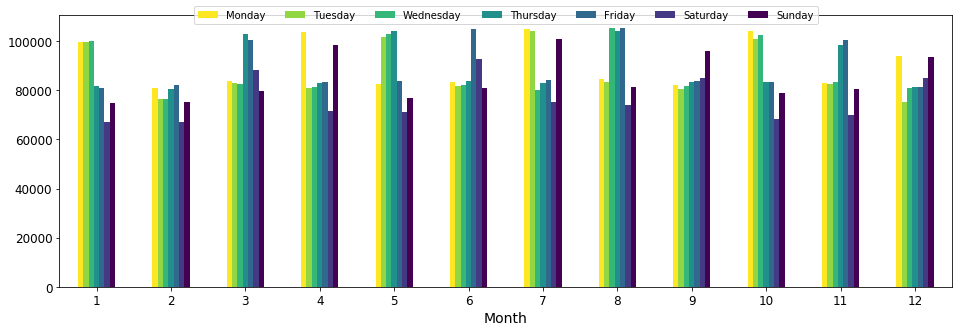

```python
# Let's plot a facetted bar chart to check the amount of flights per day of week of each month
df2 = pd.DataFrame(table)
ax = df2.plot.bar(figsize=[16,5], colormap='viridis_r')
plt.xticks(rotation=0)
ax.legend(loc='upper center', bbox_to_anchor=(0.5, 1.05), ncol=7,
          fancybox=True, shadow=False);
```

```python
# Let's get the average amount of flights per month per "DayOfWeek"
table.mean()
```

```
DayOfWeek
Monday       90648.000000
Tuesday      87529.500000
Wednesday    88320.750000
Thursday     89150.083333
Friday       89559.083333
Saturday     76302.166667
Sunday       84762.000000
dtype: float64
```

In the above facetted bar chart we don't see a certain day of week that has a constant higher amount of flights throughout the months. However, we see that Saturday tends to have the lowest amount of flights per day of week in most of the months, with a mean of 76,302 flights per month.

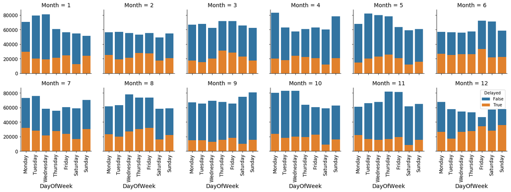

```python
# Let's plot the amount of flight operations that arrived late and not arrived late each day of week of each month
g = sns.FacetGrid(data = df_clean, col = 'Month', col_wrap = 6, hue = 'Delayed')
g.map(sns.countplot, "DayOfWeek", order=df_clean.DayOfWeek.cat.categories)
plt.legend(title = 'Delayed')
g.set_xticklabels(rotation=90);
```

```python
# Let's get our table of amount of delayed flights per day of week of each month
table = df_clean[df_clean['Delayed']==True].groupby(['Month', 'DayOfWeek']).size().unstack(fill_value=0)
table
```

| DayOfWeek Month | Monday | Tuesday | Wednesday | Thursday | Friday | Saturday | Sunday |
| --- | --- | --- | --- | --- | --- | --- | --- |
| 1 | 29211 | 20348 | 18911 | 21048 | 24525 | 12345 | 23755 |
| 2 | 24987 | 19265 | 21317 | 27704 | 27119 | 17562 | 20481 |
| 3 | 17312 | 15152 | 20193 | 31286 | 28515 | 22669 | 17562 |
| 4 | 20393 | 18014 | 23909 | 22060 | 20424 | 11700 | 20491 |
| 5 | 14717 | 19946 | 22704 | 25606 | 20590 | 11771 | 15964 |
| 6 | 26695 | 25232 | 26409 | 26098 | 33088 | 21839 | 22141 |
| 7 | 32060 | 28223 | 21763 | 27370 | 23977 | 16632 | 30289 |
| 8 | 22985 | 20125 | 27149 | 30530 | 31811 | 15953 | 22297 |
| 9 | 14947 | 14978 | 12643 | 15710 | 18345 | 10272 | 15488 |
| 10 | 23561 | 18044 | 19744 | 19547 | 22806 | 9137 | 16138 |
| 11 | 21997 | 16396 | 15700 | 16592 | 19264 | 8340 | 15391 |
| 12 | 26352 | 17291 | 26289 | 27654 | 34377 | 28148 | 35940 |

```python
# Let's get the average amount of delayed flights per month per "DayOfWeek"
table.mean()
```

```
DayOfWeek
Monday       22934.750000
Tuesday      19417.833333
Wednesday    21394.250000
Thursday     24267.083333
Friday       25403.416667
Saturday     15530.666667
Sunday       21328.083333
dtype: float64
```

In the facetted bar chart above we can see that, in our clean dataset, the amount of delayed flights per day of week is always lower than the amount of not delayed flights per day of week throughout the months. We also see that the amount of delayed flights on Saturday's is the lowest in most of the months, with a mean of 15,531 delayed flights per month. This is no surprise as Saturday was also the day with the lowest amount of flights through most of the months.

```python
# Let's get the percent of delayed flights per "DayOfWeek" per "Month"
table = df_clean.groupby(['Month', 'DayOfWeek'])['Delayed'].mean().unstack(fill_value=0)
table
```

| DayOfWeek Month | Monday | Tuesday | Wednesday | Thursday | Friday | Saturday | Sunday |
| --- | --- | --- | --- | --- | --- | --- | --- |
| 1 | 0.292467 | 0.203845 | 0.188849 | 0.257989 | 0.302830 | 0.183708 | 0.316847 |
| 2 | 0.308223 | 0.252318 | 0.278581 | 0.344273 | 0.329807 | 0.262397 | 0.271952 |
| 3 | 0.206378 | 0.182473 | 0.244201 | 0.303721 | 0.284300 | 0.256483 | 0.220205 |
| 4 | 0.196338 | 0.222615 | 0.294475 | 0.266293 | 0.245004 | 0.163394 | 0.207969 |
| 5 | 0.178099 | 0.195706 | 0.220667 | 0.246081 | 0.245218 | 0.165532 | 0.207986 |
| 6 | 0.320222 | 0.308516 | 0.321094 | 0.311927 | 0.314734 | 0.235509 | 0.273636 |
| 7 | 0.304950 | 0.271232 | 0.270950 | 0.330420 | 0.284172 | 0.221035 | 0.300120 |
| 8 | 0.271165 | 0.241004 | 0.257554 | 0.292598 | 0.301990 | 0.215107 | 0.274060 |
| 9 | 0.181826 | 0.186252 | 0.154755 | 0.188139 | 0.219170 | 0.120685 | 0.161201 |
| 10 | 0.226439 | 0.178669 | 0.192349 | 0.233922 | 0.273152 | 0.134086 | 0.204854 |
| 11 | 0.265645 | 0.198884 | 0.188552 | 0.168165 | 0.191525 | 0.119346 | 0.191554 |
| 12 | 0.279974 | 0.230203 | 0.325230 | 0.340277 | 0.423102 | 0.330686 | 0.384702 |

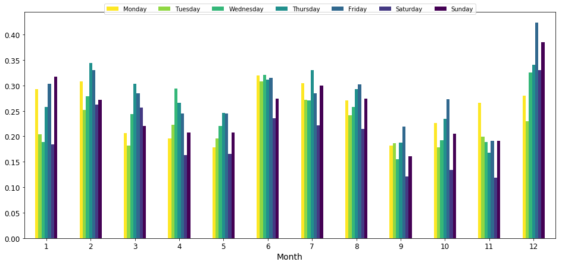

```python
# Let's plot a facetted bar chart to check the percent of delayed flights per "DayOfWeek" per "Month"
df2 = pd.DataFrame(table)
ax = df2.plot.bar(figsize=[16,7], colormap='viridis_r')
ax.legend(loc='upper center', bbox_to_anchor=(0.5, 1.05), ncol=12,
          fancybox=True, shadow=False)
plt.xticks(rotation=0);
```

In the facetted bar chart above we can see that, in our clean dataset, on average the percentage of delayed flights per day of week hits its lowest on Saturday through most of the months.

**#3: What is the distribution of flight operations that arrived late each weekend and weekday per month? Is there any pattern?**

```python
# Let's check the amount of delayed and not delayed flights per weekday and weekend per month
table = df_clean.groupby(['Month', 'Weekday_Weekend'])['Delayed'].value_counts().unstack(fill_value=0)
table
```

| Month | Delayed Weekday_Weekend | False | True |
| --- | --- | --- | --- |
| 1 | Weekday | 348365 | 114043 |
|  | Weekend | 106072 | 36100 |
| 2 | Weekday | 276246 | 120392 |
|  | Weekend | 104197 | 38043 |
| 3 | Weekday | 340462 | 112458 |
|  | Weekend | 127906 | 40231 |
| 4 | Weekday | 327382 | 104800 |
|  | Weekend | 137944 | 32191 |
| 5 | Weekday | 371898 | 103563 |
|  | Weekend | 120130 | 27735 |
| 6 | Weekday | 298671 | 137522 |
|  | Weekend | 129665 | 43980 |
| 7 | Weekday | 323324 | 133393 |
|  | Weekend | 129248 | 46921 |
| 8 | Weekday | 350759 | 132600 |
|  | Weekend | 117271 | 38250 |
| 9 | Weekday | 334901 | 76623 |
|  | Weekend | 155433 | 25760 |
| 10 | Weekday | 371040 | 103702 |
|  | Weekend | 121646 | 25275 |
| 11 | Weekday | 357810 | 89949 |
|  | Weekend | 126498 | 23731 |
| 12 | Weekday | 280623 | 131963 |
|  | Weekend | 114455 | 64088 |

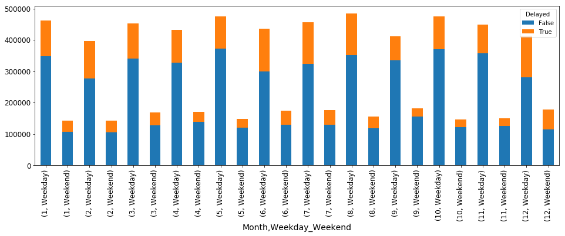

```python
# Let's plot the amount of delayed and not delayed flights per weekday and weekend per month
df2 = pd.DataFrame(table)
df2.plot.bar(figsize=[16,5], stacked=True);
```

In the stacked bar chart above we can see that, in our clean dataset, weekdays have a higher amount of flights per month than weekends through all the months. We can also see that the amount of delayed flights is low during both weekends and weekdays throughout the months.

Let's check the percentage of those delayed flights per weekday/weekend of each month.

```python
# Let's get our table of percents per weekday/weekend of each month, out of the delayed flights
c = df_clean[df_clean['Delayed']==True].groupby(['Month', 'Weekday_Weekend'])['Delayed'].sum().rename("count")
table = c / c.groupby(level=0).sum()
table = table.unstack(fill_value=0)
table
```

| Weekday_Weekend Month | Weekday | Weekend |
| --- | --- | --- |
| 1 | 0.759563 | 0.240437 |
| 2 | 0.759883 | 0.240117 |
| 3 | 0.736517 | 0.263483 |
| 4 | 0.765014 | 0.234986 |
| 5 | 0.788763 | 0.211237 |
| 6 | 0.757689 | 0.242311 |
| 7 | 0.739782 | 0.260218 |
| 8 | 0.776119 | 0.223881 |
| 9 | 0.748396 | 0.251604 |
| 10 | 0.804035 | 0.195965 |
| 11 | 0.791247 | 0.208753 |
| 12 | 0.673105 | 0.326895 |

```python
# Let's check the average percent per month per weekday/weekend, out of the delayed flights
table.mean()
```

```
Weekday_Weekend
Weekday    0.758343
Weekend    0.241657
dtype: float64
```

In our clean dataset, out of the delayed flights per month, on average 76% of them happened on weekdays.

```python
# Let's get the percent of delayed flights per "Weekday_Weekend" per "Month"
table = df_clean.groupby(['Month', 'Weekday_Weekend'])['Delayed'].mean().unstack(fill_value=0)
table
```

| Weekday_Weekend Month | Weekday | Weekend |
| --- | --- | --- |
| 1 | 0.246629 | 0.253918 |
| 2 | 0.303531 | 0.267456 |
| 3 | 0.248296 | 0.239275 |
| 4 | 0.242490 | 0.189209 |
| 5 | 0.217816 | 0.187570 |
| 6 | 0.315278 | 0.253275 |
| 7 | 0.292069 | 0.266341 |
| 8 | 0.274330 | 0.245947 |
| 9 | 0.186193 | 0.142169 |
| 10 | 0.218439 | 0.172031 |
| 11 | 0.200887 | 0.157966 |
| 12 | 0.319844 | 0.358950 |

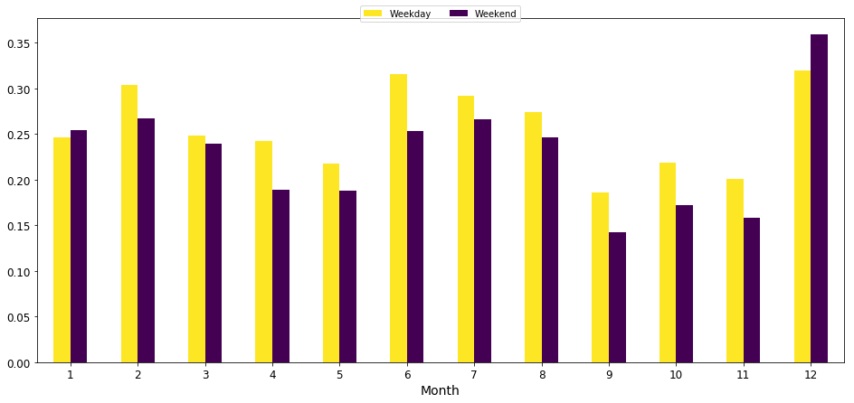

```python
# Let's plot a facetted bar chart to check the percent of delayed flights per "Weekday_Weekend" per "Month"
df2 = pd.DataFrame(table)
ax = df2.plot.bar(figsize=[16,7], colormap='viridis_r')
ax.legend(loc='upper center', bbox_to_anchor=(0.5, 1.05), ncol=12,
          fancybox=True, shadow=False)
plt.xticks(rotation=0);
```

In the facetted bar chart above we can see that, in our clean dataset, on average the percentage of delayed flights is similar for both weekdays and weekends. However, the percentage of delayed flights is higher on weekdays in most of the months.

**#4: What is the distribution of flight operations that arrived late per hour (Schedule Arrival Time) each month? Is there any pattern?**

```python
# Let's first get a table of amount of flights per "CRSArrivalTime" of each month
table = df_clean.groupby(['Month', 'CRSArrivalTime']).size().unstack(fill_value=0)
table
```

| CRSArrivalTime Month | 0 AM | 1 AM | 2 AM | 3 AM | 4 AM | 5 AM | 6 AM | 7 AM | 8 AM | 9 AM | 10 AM | 11 AM | 12 PM | 1 PM | 2 PM | 3 PM | 4 PM | 5 PM | 6 PM | 7 PM | 8 PM | 9 PM | 10 PM | 11 PM |
| --- | --- | --- | --- | --- | --- | --- | --- | --- | --- | --- | --- | --- | --- | --- | --- | --- | --- | --- | --- | --- | --- | --- | --- | --- |
| 1 | 3599 | 747 | 260 | 107 | 438 | 3039 | 5763 | 18656 | 30225 | 33837 | 41290 | 37397 | 38792 | 35714 | 38423 | 36536 | 43992 | 37917 | 39558 | 36955 | 40141 | 33718 | 29250 | 18226 |
| 2 | 3334 | 703 | 237 | 91 | 408 | 2791 | 5111 | 16900 | 27035 | 30125 | 36994 | 33143 | 34434 | 32318 | 33643 | 32596 | 39094 | 34006 | 35204 | 32602 | 35454 | 29937 | 26376 | 16342 |
| 3 | 4451 | 829 | 286 | 166 | 421 | 3363 | 6388 | 20620 | 32091 | 35620 | 42193 | 38511 | 40089 | 36386 | 39136 | 37251 | 42914 | 39555 | 40663 | 36545 | 40959 | 33900 | 30335 | 18385 |
| 4 | 3983 | 876 | 263 | 188 | 322 | 3176 | 6130 | 20447 | 31044 | 34851 | 40004 | 37556 | 38784 | 34718 | 38239 | 36492 | 40714 | 38970 | 40201 | 35204 | 39791 | 32977 | 29584 | 17803 |
| 5 | 3651 | 917 | 215 | 216 | 242 | 3052 | 6714 | 21461 | 31961 | 36946 | 41015 | 38937 | 39889 | 36159 | 39759 | 37951 | 42148 | 40050 | 41923 | 36737 | 41345 | 33853 | 29989 | 18196 |
| 6 | 4151 | 1196 | 292 | 157 | 504 | 3378 | 6854 | 21846 | 30771 | 37144 | 40396 | 37977 | 39893 | 34714 | 39212 | 36519 | 41084 | 38371 | 40311 | 35885 | 39856 | 32007 | 29333 | 17987 |
| 7 | 4541 | 1278 | 297 | 196 | 549 | 3716 | 6924 | 22833 | 31347 | 38306 | 41109 | 39163 | 41567 | 35715 | 40200 | 38488 | 42056 | 40168 | 41778 | 37618 | 40988 | 34183 | 30581 | 19285 |
| 8 | 4506 | 1214 | 260 | 166 | 535 | 3561 | 6886 | 23423 | 31911 | 38473 | 41815 | 39082 | 41949 | 36027 | 40298 | 38823 | 42235 | 40695 | 42285 | 37832 | 41662 | 34839 | 30773 | 19630 |
| 9 | 3533 | 626 | 190 | 116 | 392 | 2932 | 5489 | 20807 | 29215 | 34649 | 38485 | 37547 | 38550 | 34665 | 37881 | 37488 | 40715 | 38910 | 39470 | 36279 | 38667 | 31837 | 27118 | 17156 |
| 10 | 3652 | 633 | 178 | 149 | 406 | 3017 | 5851 | 22153 | 30908 | 36212 | 40303 | 39126 | 40432 | 36875 | 39510 | 38813 | 42698 | 40561 | 41342 | 37873 | 40659 | 33099 | 29015 | 18198 |
| 11 | 4446 | 511 | 297 | 89 | 505 | 2989 | 5523 | 19971 | 30463 | 34501 | 39857 | 35434 | 40352 | 36699 | 36961 | 37589 | 42404 | 36945 | 39222 | 35761 | 39344 | 31838 | 28390 | 17897 |
| 12 | 4870 | 580 | 325 | 111 | 438 | 3045 | 5789 | 19383 | 29431 | 33499 | 39681 | 34998 | 39746 | 36482 | 36646 | 37039 | 41924 | 36608 | 38991 | 34667 | 39275 | 31098 | 27846 | 18657 |

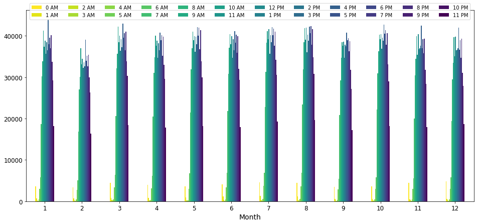

```python
# Let's plot a facetted bar chart to check the amount of flights per "CRSArrivalTime" of each month
df2 = pd.DataFrame(table)
ax = df2.plot.bar(figsize=[16,7], colormap='viridis_r')
ax.legend(loc='upper center', bbox_to_anchor=(0.5, 1.05),
          ncol=12, fancybox=True, shadow=False)
plt.xticks(rotation=0);
```

```python
# Let's get the average amount of flights per month per "CRSArrivalTime"
table.mean()
```

```
CRSArrivalTime
0 AM      4059.750000
1 AM       842.500000
2 AM       258.333333
3 AM       146.000000
4 AM       430.000000
5 AM      3171.583333
6 AM      6118.500000
7 AM     20708.333333
8 AM     30533.500000
9 AM     35346.916667
10 AM    40261.833333
11 AM    37405.916667
12 PM    39539.750000
1 PM     35539.333333
2 PM     38325.666667
3 PM     37132.083333
4 PM     41831.500000
5 PM     38563.000000
6 PM     40079.000000
7 PM     36163.166667
8 PM     39845.083333
9 PM     32773.833333
10 PM    29049.166667
11 PM    18146.833333
dtype: float64
```

In the above facetted bar chart we can see that, in our clean dataset, the pattern identified during the univariate analysis gets repeated throughout the months: There is a clear flight reduction between 0 AM and 6 AM (inclusive) throughout the months.

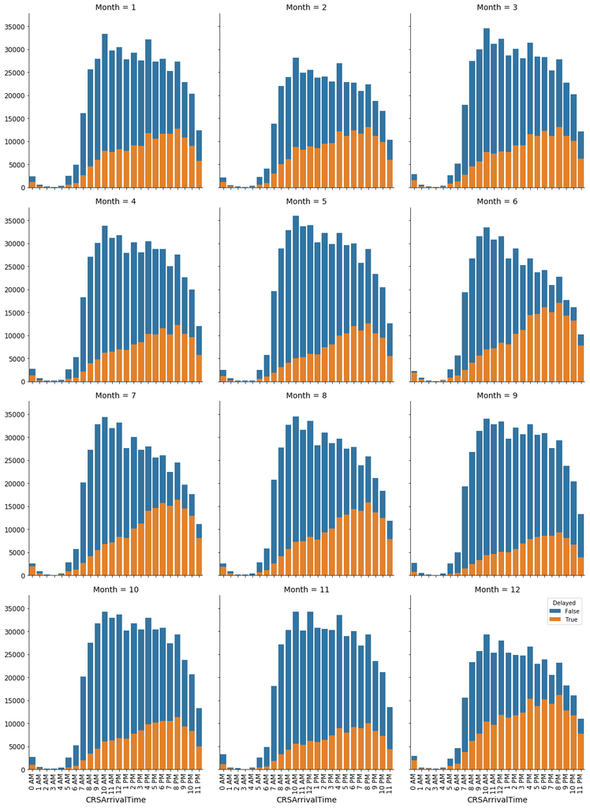

```python
# Let's plot the amount of flight operations that arrived late and not arrived late each "CRSArrivalTime" of each month
g = sns.FacetGrid(data = df_clean, col = 'Month', col_wrap = 3, hue = 'Delayed', size = 5)
g.map(sns.countplot, "CRSArrivalTime", order=df_clean.CRSArrivalTime.cat.categories)
plt.legend(title = 'Delayed')
g.set_xticklabels(rotation=90);
```

```python
# Let's get our table of amount of delayed flights per "CRSArrivalTime" of each month
table = df_clean[df_clean['Delayed']==True].groupby(['Month', 'CRSArrivalTime']).size().unstack(fill_value=0)
table
```

| CRSArrivalTime Month | 0 AM | 1 AM | 2 AM | 3 AM | 4 AM | 5 AM | 6 AM | 7 AM | 8 AM | 9 AM | 10 AM | 11 AM | 12 PM | 1 PM | 2 PM | 3 PM | 4 PM | 5 PM | 6 PM | 7 PM | 8 PM | 9 PM | 10 PM | 11 PM |
| --- | --- | --- | --- | --- | --- | --- | --- | --- | --- | --- | --- | --- | --- | --- | --- | --- | --- | --- | --- | --- | --- | --- | --- | --- |
| 1 | 1160 | 200 | 94 | 55 | 60 | 536 | 894 | 2586 | 4599 | 5959 | 7958 | 7625 | 8343 | 7919 | 9108 | 8961 | 11807 | 10559 | 11674 | 11618 | 12796 | 10867 | 8970 | 5795 |
| 2 | 1200 | 220 | 70 | 41 | 75 | 573 | 983 | 3017 | 5030 | 6171 | 8811 | 8210 | 8903 | 8475 | 9547 | 9626 | 12137 | 11141 | 12432 | 11714 | 13082 | 11129 | 9834 | 6014 |
| 3 | 1567 | 253 | 118 | 57 | 95 | 786 | 1292 | 2692 | 4593 | 5676 | 7651 | 7302 | 7852 | 7743 | 9077 | 9148 | 11502 | 11153 | 12321 | 11158 | 13149 | 11122 | 10104 | 6278 |
| 4 | 1237 | 229 | 94 | 47 | 44 | 539 | 846 | 2164 | 3941 | 4724 | 6251 | 6421 | 6971 | 6820 | 8067 | 8453 | 10319 | 10193 | 11506 | 10186 | 12211 | 10343 | 9631 | 5754 |
| 5 | 1139 | 243 | 65 | 55 | 52 | 596 | 1026 | 1829 | 3041 | 4059 | 4979 | 5296 | 5943 | 5912 | 7477 | 8060 | 9960 | 10468 | 11946 | 11014 | 12613 | 10487 | 9500 | 5538 |
| 6 | 1868 | 396 | 86 | 56 | 146 | 831 | 1285 | 2468 | 4015 | 5672 | 6904 | 7147 | 8428 | 8029 | 10315 | 11208 | 14379 | 14635 | 16136 | 15025 | 17097 | 14328 | 13233 | 7815 |
| 7 | 1959 | 436 | 89 | 93 | 141 | 917 | 1254 | 2703 | 4085 | 5510 | 6734 | 7147 | 8362 | 8062 | 10115 | 11211 | 13997 | 14619 | 15730 | 15127 | 16479 | 14523 | 12887 | 8134 |
| 8 | 1896 | 362 | 76 | 56 | 104 | 697 | 1079 | 2635 | 4096 | 5769 | 7309 | 7437 | 8354 | 7807 | 9302 | 10123 | 12547 | 13145 | 14381 | 13981 | 15803 | 13652 | 12414 | 7825 |
| 9 | 795 | 90 | 41 | 18 | 44 | 312 | 544 | 1491 | 2442 | 3309 | 4429 | 4681 | 5072 | 4989 | 5736 | 6875 | 7938 | 8336 | 8627 | 8604 | 9343 | 8077 | 6720 | 3870 |
| 10 | 1001 | 116 | 44 | 19 | 73 | 415 | 706 | 1997 | 3408 | 4474 | 6011 | 6258 | 6769 | 6694 | 7739 | 8401 | 9741 | 10174 | 10539 | 10450 | 11305 | 9352 | 8377 | 4914 |
| 11 | 1146 | 105 | 47 | 9 | 94 | 439 | 640 | 1860 | 3320 | 4193 | 5595 | 5265 | 6124 | 5977 | 6466 | 7323 | 8902 | 8011 | 9138 | 8909 | 10028 | 8361 | 7309 | 4419 |
| 12 | 1949 | 171 | 90 | 27 | 108 | 769 | 1217 | 3788 | 6136 | 7787 | 10429 | 9699 | 11805 | 11169 | 11745 | 12350 | 15308 | 13735 | 15158 | 14186 | 16118 | 12846 | 11755 | 7706 |

```python
# Let's get the average amount of delayed flights per month per "CRSArrivalTime"
table.mean()
```

```
CRSArrivalTime
0 AM      1409.750000
1 AM       235.083333
2 AM        76.166667
3 AM        44.416667
4 AM        86.333333
5 AM       617.500000
6 AM       980.500000
7 AM      2435.833333
8 AM      4058.833333
9 AM      5275.250000
10 AM     6921.750000
11 AM     6874.000000
12 PM     7743.833333
1 PM      7466.333333
2 PM      8724.500000
3 PM      9311.583333
4 PM     11544.750000
5 PM     11347.416667
6 PM     12465.666667
7 PM     11831.000000
8 PM     13335.333333
9 PM     11257.250000
10 PM    10061.166667
11 PM     6171.833333
dtype: float64
```

In the facetted bar chart above we can see that, in our clean dataset, the amount of delayed flights per Scheduled Arrival Time (hour) is always lower than the amount of not delayed flights per Scheduled Arrival Time (hour) throughout the months. We also see that the amount of delayed flights is the lowest between 1 AM - 4 AM (inclusive) every month, being 44 delayed flights the lowest average per hour. This is no surprise because the amount of flights is also low during those hours.

```python
# Let's get the percent of delayed flights per "CRSArrivalTime" per "Month"
table = df_clean.groupby(['Month', 'CRSArrivalTime'])['Delayed'].mean().unstack(fill_value=0)
table
```

| CRSArrivalTime Month | 0 AM | 1 AM | 2 AM | 3 AM | 4 AM | 5 AM | 6 AM | 7 AM | 8 AM | 9 AM | 10 AM | 11 AM | 12 PM | 1 PM | 2 PM | 3 PM | 4 PM | 5 PM | 6 PM | 7 PM | 8 PM | 9 PM | 10 PM | 11 PM |
| --- | --- | --- | --- | --- | --- | --- | --- | --- | --- | --- | --- | --- | --- | --- | --- | --- | --- | --- | --- | --- | --- | --- | --- | --- |
| 1 | 0.322312 | 0.267738 | 0.361538 | 0.514019 | 0.136986 | 0.176374 | 0.155128 | 0.138615 | 0.152159 | 0.176109 | 0.192734 | 0.203893 | 0.215070 | 0.221734 | 0.237046 | 0.245265 | 0.268390 | 0.278477 | 0.295111 | 0.314382 | 0.318776 | 0.322291 | 0.306667 | 0.317952 |
| 2 | 0.359928 | 0.312945 | 0.295359 | 0.450549 | 0.183824 | 0.205303 | 0.192330 | 0.178521 | 0.186055 | 0.204846 | 0.238174 | 0.247714 | 0.258553 | 0.262238 | 0.283774 | 0.295312 | 0.310457 | 0.327619 | 0.353142 | 0.359303 | 0.368985 | 0.371747 | 0.372839 | 0.368009 |
| 3 | 0.352056 | 0.305187 | 0.412587 | 0.343373 | 0.225653 | 0.233720 | 0.202254 | 0.130553 | 0.143124 | 0.159349 | 0.181333 | 0.189608 | 0.195864 | 0.212802 | 0.231935 | 0.245577 | 0.268024 | 0.281962 | 0.303003 | 0.305322 | 0.321028 | 0.328083 | 0.333081 | 0.341474 |
| 4 | 0.310570 | 0.261416 | 0.357414 | 0.250000 | 0.136646 | 0.169710 | 0.138010 | 0.105835 | 0.126949 | 0.135548 | 0.156259 | 0.170971 | 0.179739 | 0.196440 | 0.210963 | 0.231640 | 0.253451 | 0.261560 | 0.286212 | 0.289342 | 0.306878 | 0.313643 | 0.325548 | 0.323204 |
| 5 | 0.311969 | 0.264995 | 0.302326 | 0.254630 | 0.214876 | 0.195282 | 0.152815 | 0.085224 | 0.095147 | 0.109863 | 0.121395 | 0.136015 | 0.148988 | 0.163500 | 0.188058 | 0.212379 | 0.236310 | 0.261373 | 0.284951 | 0.299807 | 0.305067 | 0.309781 | 0.316783 | 0.304353 |
| 6 | 0.450012 | 0.331104 | 0.294521 | 0.356688 | 0.289683 | 0.246004 | 0.187482 | 0.112973 | 0.130480 | 0.152703 | 0.170908 | 0.188193 | 0.211265 | 0.231290 | 0.263057 | 0.306909 | 0.349990 | 0.381408 | 0.400288 | 0.418699 | 0.428969 | 0.447652 | 0.451130 | 0.434480 |
| 7 | 0.431403 | 0.341158 | 0.299663 | 0.474490 | 0.256831 | 0.246771 | 0.181109 | 0.118381 | 0.130316 | 0.143842 | 0.163808 | 0.182494 | 0.201169 | 0.225731 | 0.251617 | 0.291286 | 0.332818 | 0.363946 | 0.376514 | 0.402121 | 0.402045 | 0.424860 | 0.421405 | 0.421779 |
| 8 | 0.420772 | 0.298188 | 0.292308 | 0.337349 | 0.194393 | 0.195732 | 0.156695 | 0.112496 | 0.128357 | 0.149949 | 0.174794 | 0.190292 | 0.199147 | 0.216699 | 0.230830 | 0.260747 | 0.297076 | 0.323013 | 0.340097 | 0.369555 | 0.379314 | 0.391860 | 0.403406 | 0.398625 |
| 9 | 0.225021 | 0.143770 | 0.215789 | 0.155172 | 0.112245 | 0.106412 | 0.099107 | 0.071659 | 0.083587 | 0.095501 | 0.115084 | 0.124670 | 0.131569 | 0.143920 | 0.151422 | 0.183392 | 0.194965 | 0.214238 | 0.218571 | 0.237162 | 0.241627 | 0.253699 | 0.247806 | 0.225577 |
| 10 | 0.274096 | 0.183254 | 0.247191 | 0.127517 | 0.179803 | 0.137554 | 0.120663 | 0.090146 | 0.110263 | 0.123550 | 0.149145 | 0.159945 | 0.167417 | 0.181532 | 0.195874 | 0.216448 | 0.228137 | 0.250832 | 0.254922 | 0.275922 | 0.278044 | 0.282546 | 0.288713 | 0.270030 |
| 11 | 0.257760 | 0.205479 | 0.158249 | 0.101124 | 0.186139 | 0.146872 | 0.115879 | 0.093135 | 0.108985 | 0.121533 | 0.140377 | 0.148586 | 0.151764 | 0.162865 | 0.174941 | 0.194818 | 0.209933 | 0.216836 | 0.232981 | 0.249126 | 0.254880 | 0.262611 | 0.257450 | 0.246913 |
| 12 | 0.400205 | 0.294828 | 0.276923 | 0.243243 | 0.246575 | 0.252545 | 0.210226 | 0.195429 | 0.208488 | 0.232455 | 0.262821 | 0.277130 | 0.297011 | 0.306151 | 0.320499 | 0.333432 | 0.365137 | 0.375191 | 0.388756 | 0.409208 | 0.410388 | 0.413081 | 0.422143 | 0.413035 |

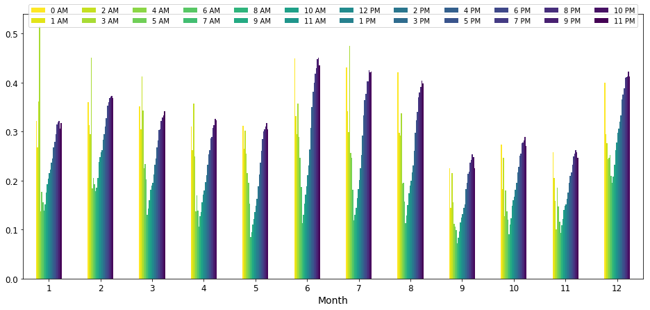

```python
# Let's plot a facetted bar chart to check the percent of delayed flights per "CRSArrivalTime" per "Month"
df2 = pd.DataFrame(table)
ax = df2.plot.bar(figsize=[16,7], colormap='viridis_r')
ax.legend(loc='upper center', bbox_to_anchor=(0.5, 1.05), ncol=12,
          fancybox=True, shadow=False)
plt.xticks(rotation=0);
```

In the facetted bar chart above we can see that, in our clean dataset, on average the percentage of delayed flights per scheduled arrival hour hits its lowest at 7 AM through most of the months.

**#5: What is the distribution of flight operations that arrived late per hour (Schedule Arrival Time) each day of week? Is there any pattern?**

```python
# Let's first get a table of amount of flights per "CRSArrivalTime" of each day of week
table = df_clean.groupby(['DayOfWeek', 'CRSArrivalTime']).size().unstack(fill_value=0)
table
```

| CRSArrivalTime DayOfWeek | 0 AM | 1 AM | 2 AM | 3 AM | 4 AM | 5 AM | 6 AM | 7 AM | 8 AM | 9 AM | 10 AM | 11 AM | 12 PM | 1 PM | 2 PM | 3 PM | 4 PM | 5 PM | 6 PM | 7 PM | 8 PM | 9 PM | 10 PM | 11 PM |
| --- | --- | --- | --- | --- | --- | --- | --- | --- | --- | --- | --- | --- | --- | --- | --- | --- | --- | --- | --- | --- | --- | --- | --- | --- |
| Monday | 7401 | 1500 | 445 | 240 | 711 | 5618 | 11211 | 38232 | 56355 | 63917 | 72243 | 65951 | 70584 | 63150 | 68176 | 65673 | 74377 | 68618 | 71428 | 64493 | 72180 | 59536 | 53033 | 32704 |
| Tuesday | 6844 | 1205 | 315 | 182 | 647 | 5281 | 10601 | 37840 | 55550 | 62205 | 69695 | 64013 | 66908 | 60545 | 65305 | 63255 | 71850 | 66611 | 69347 | 62675 | 69973 | 57438 | 50829 | 31240 |
| Wednesday | 6924 | 1373 | 394 | 212 | 683 | 5386 | 10932 | 38091 | 55683 | 62501 | 70076 | 63986 | 68454 | 60761 | 65973 | 63806 | 72260 | 67114 | 69773 | 63068 | 70655 | 58129 | 51794 | 31821 |
| Thursday | 7280 | 1612 | 521 | 262 | 761 | 5574 | 11275 | 38594 | 56307 | 63591 | 71426 | 65046 | 69491 | 62015 | 66854 | 64296 | 72595 | 66870 | 69591 | 62793 | 70279 | 58361 | 52166 | 32241 |
| Friday | 7375 | 1658 | 533 | 300 | 809 | 5708 | 11134 | 38383 | 56000 | 63419 | 71358 | 65007 | 69532 | 62100 | 66986 | 64603 | 72924 | 67547 | 70271 | 63504 | 71018 | 59137 | 52564 | 32839 |
| Saturday | 5330 | 1112 | 354 | 252 | 729 | 5244 | 9318 | 30245 | 45646 | 54880 | 64226 | 62260 | 62749 | 57515 | 60903 | 60315 | 66109 | 59072 | 60905 | 54083 | 53244 | 41643 | 35494 | 23998 |
| Sunday | 7563 | 1650 | 538 | 304 | 820 | 5248 | 8951 | 27115 | 40861 | 53650 | 64118 | 62608 | 66759 | 60386 | 65711 | 63637 | 71863 | 66924 | 69633 | 63342 | 70792 | 59042 | 52710 | 32919 |

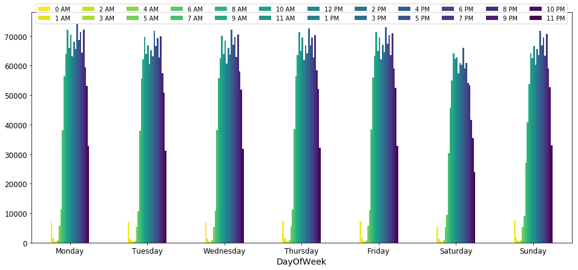

```python
# Let's plot a facetted bar chart to check the amount of flights per "CRSArrivalTime" of each day of week
df2 = pd.DataFrame(table)
ax = df2.plot.bar(figsize=[16,7], colormap='viridis_r')
ax.legend(loc='upper center', bbox_to_anchor=(0.5, 1.05),
          ncol=12, fancybox=True, shadow=False)
plt.xticks(rotation=0);
```

```python
# Let's get the average amount of flights per day of week per "CRSArrivalTime"
table.mean()
```

```
CRSArrivalTime
0 AM      6959.571429
1 AM      1444.285714
2 AM       442.857143
3 AM       250.285714
4 AM       737.142857
5 AM      5437.000000
6 AM     10488.857143
7 AM     35500.000000
8 AM     52343.142857
9 AM     60594.714286
10 AM    69020.285714
11 AM    64124.428571
12 PM    67782.428571
1 PM     60924.571429
2 PM     65701.142857
3 PM     63655.000000
4 PM     71711.142857
5 PM     66108.000000
6 PM     68706.857143
7 PM     61994.000000
8 PM     68305.857143
9 PM     56183.714286
10 PM    49798.571429
11 PM    31108.857143
dtype: float64
```

In the above facetted bar chart we can see that, in our clean dataset, there is a clear flight reduction between 0 AM and 6 AM (inclusive) throughout the days of week.

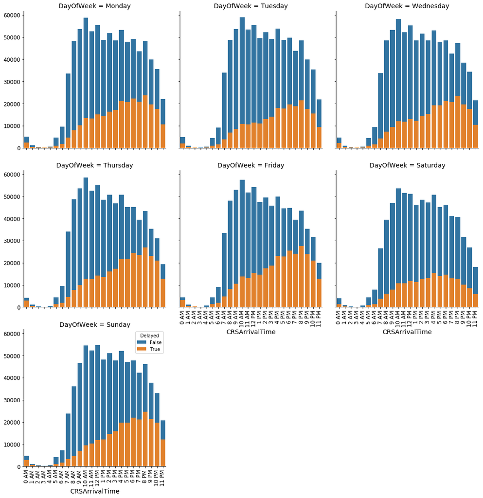

```python
# Let's plot the amount of flights that arrived late and not arrived late each "CRSArrivalTime" of each day of week
g = sns.FacetGrid(data = df_clean, col = 'DayOfWeek', col_wrap = 3, hue = 'Delayed', size = 5)
g.map(sns.countplot, "CRSArrivalTime", order=df_clean.CRSArrivalTime.cat.categories)
plt.legend(title = 'Delayed')
g.set_xticklabels(rotation=90);
```

```python
# Let's get our table of amount of delayed flights per "CRSArrivalTime" of each day of week
table = df_clean[df_clean['Delayed']==True].groupby(['DayOfWeek', 'CRSArrivalTime']).size().unstack(fill_value=0)
table
```

| CRSArrivalTime DayOfWeek | 0 AM | 1 AM | 2 AM | 3 AM | 4 AM | 5 AM | 6 AM | 7 AM | 8 AM | 9 AM | 10 AM | 11 AM | 12 PM | 1 PM | 2 PM | 3 PM | 4 PM | 5 PM | 6 PM | 7 PM | 8 PM | 9 PM | 10 PM | 11 PM |
| --- | --- | --- | --- | --- | --- | --- | --- | --- | --- | --- | --- | --- | --- | --- | --- | --- | --- | --- | --- | --- | --- | --- | --- | --- |
| Monday | 2420 | 410 | 116 | 62 | 120 | 1011 | 1703 | 4679 | 8020 | 10178 | 13421 | 13313 | 15057 | 14482 | 16373 | 17173 | 21182 | 20634 | 22290 | 20943 | 23816 | 19694 | 17528 | 10592 |
| Tuesday | 2003 | 265 | 68 | 36 | 112 | 925 | 1504 | 3923 | 6839 | 8472 | 10760 | 10522 | 11469 | 10986 | 13068 | 14041 | 17995 | 17864 | 19558 | 18828 | 21360 | 17612 | 15443 | 9361 |
| Wednesday | 2264 | 329 | 93 | 50 | 127 | 995 | 1647 | 4288 | 7258 | 9332 | 12030 | 11797 | 13149 | 12318 | 14384 | 15370 | 19297 | 19265 | 21330 | 20557 | 23353 | 19575 | 17500 | 10423 |
| Thursday | 2993 | 521 | 176 | 94 | 171 | 1240 | 1842 | 4549 | 7744 | 9911 | 12855 | 12529 | 14195 | 13591 | 16166 | 17395 | 21831 | 21748 | 24380 | 23448 | 26871 | 23076 | 21045 | 12834 |
| Friday | 3064 | 513 | 200 | 118 | 189 | 1228 | 1927 | 4792 | 8033 | 10533 | 13784 | 13261 | 15427 | 14714 | 17583 | 18723 | 23115 | 22934 | 25484 | 24114 | 27477 | 23775 | 21007 | 12846 |
| Saturday | 1363 | 221 | 82 | 69 | 125 | 921 | 1397 | 3785 | 6126 | 7873 | 10665 | 10782 | 11711 | 11366 | 12525 | 13184 | 15436 | 13970 | 14669 | 13028 | 12510 | 10092 | 8582 | 5886 |
| Sunday | 2810 | 562 | 179 | 104 | 192 | 1090 | 1746 | 3214 | 4686 | 7004 | 9546 | 10284 | 11918 | 12139 | 14595 | 15853 | 19681 | 19754 | 21877 | 21054 | 24637 | 21263 | 19629 | 12120 |

```python
# Let's get the average amount of delayed flights per day of week per "CRSArrivalTime"
table.mean()
```

```
CRSArrivalTime
0 AM      2416.714286
1 AM       403.000000
2 AM       130.571429
3 AM        76.142857
4 AM       148.000000
5 AM      1058.571429
6 AM      1680.857143
7 AM      4175.714286
8 AM      6958.000000
9 AM      9043.285714
10 AM    11865.857143
11 AM    11784.000000
12 PM    13275.142857
1 PM     12799.428571
2 PM     14956.285714
3 PM     15962.714286
4 PM     19791.000000
5 PM     19452.714286
6 PM     21369.714286
7 PM     20281.714286
8 PM     22860.571429
9 PM     19298.142857
10 PM    17247.714286
11 PM    10580.285714
dtype: float64
```

In the facetted bar chart above we can see that, in our clean dataset, the amount of delayed flights per Scheduled Arrival Time (hour) is always lower than the amount of not delayed flights per Scheduled Arrival Time (hour) throughout the days of week. We also see that the amount of delayed flights is the lowest between 1 AM - 4 AM (inclusive) every day of week, being 76 delayed flights the lowest average per hour. This is no surprise because the amount of flights is also low during those hours throughout the days of week.

```python
# Let's get the percent of delayed flights per 'DayOfWeek' per 'CRSArrivalTime'
table = df_clean.groupby(['CRSArrivalTime', 'DayOfWeek'])['Delayed'].mean().unstack(fill_value=0)
table
```

| DayOfWeek CRSArrivalTime | Monday | Tuesday | Wednesday | Thursday | Friday | Saturday | Sunday |
| --- | --- | --- | --- | --- | --- | --- | --- |
| 0 AM | 0.326983 | 0.292665 | 0.326979 | 0.411126 | 0.415458 | 0.255722 | 0.371546 |
| 1 AM | 0.273333 | 0.219917 | 0.239621 | 0.323201 | 0.309409 | 0.198741 | 0.340606 |
| 2 AM | 0.260674 | 0.215873 | 0.236041 | 0.337812 | 0.375235 | 0.231638 | 0.332714 |
| 3 AM | 0.258333 | 0.197802 | 0.235849 | 0.358779 | 0.393333 | 0.273810 | 0.342105 |
| 4 AM | 0.168776 | 0.173107 | 0.185944 | 0.224704 | 0.233622 | 0.171468 | 0.234146 |
| 5 AM | 0.179957 | 0.175156 | 0.184738 | 0.222461 | 0.215137 | 0.175629 | 0.207698 |
| 6 AM | 0.151904 | 0.141873 | 0.150659 | 0.163370 | 0.173073 | 0.149925 | 0.195062 |
| 7 AM | 0.122384 | 0.103673 | 0.112573 | 0.117868 | 0.124847 | 0.125145 | 0.118532 |
| 8 AM | 0.142312 | 0.123114 | 0.130345 | 0.137532 | 0.143446 | 0.134207 | 0.114681 |
| 9 AM | 0.159238 | 0.136195 | 0.149310 | 0.155855 | 0.166086 | 0.143458 | 0.130550 |
| 10 AM | 0.185776 | 0.154387 | 0.171671 | 0.179976 | 0.193167 | 0.166054 | 0.148882 |
| 11 AM | 0.201862 | 0.164373 | 0.184368 | 0.192618 | 0.203993 | 0.173177 | 0.164260 |
| 12 PM | 0.213320 | 0.171414 | 0.192085 | 0.204271 | 0.221869 | 0.186632 | 0.178523 |
| 1 PM | 0.229327 | 0.181452 | 0.202729 | 0.219157 | 0.236940 | 0.197618 | 0.201023 |
| 2 PM | 0.240158 | 0.200107 | 0.218029 | 0.241811 | 0.262488 | 0.205655 | 0.222109 |
| 3 PM | 0.261493 | 0.221975 | 0.240886 | 0.270546 | 0.289816 | 0.218586 | 0.249116 |
| 4 PM | 0.284792 | 0.250452 | 0.267050 | 0.300723 | 0.316974 | 0.233493 | 0.273868 |
| 5 PM | 0.300708 | 0.268184 | 0.287049 | 0.325228 | 0.339527 | 0.236491 | 0.295171 |
| 6 PM | 0.312062 | 0.282031 | 0.305706 | 0.350333 | 0.362653 | 0.240851 | 0.314176 |
| 7 PM | 0.324733 | 0.300407 | 0.325950 | 0.373417 | 0.379724 | 0.240889 | 0.332386 |
| 8 PM | 0.329953 | 0.305261 | 0.330522 | 0.382348 | 0.386902 | 0.234956 | 0.348020 |
| 9 PM | 0.330791 | 0.306626 | 0.336751 | 0.395401 | 0.402033 | 0.242346 | 0.360133 |
| 10 PM | 0.330511 | 0.303823 | 0.337877 | 0.403424 | 0.399646 | 0.241787 | 0.372396 |
| 11 PM | 0.323875 | 0.299648 | 0.327551 | 0.398065 | 0.391181 | 0.245270 | 0.368176 |

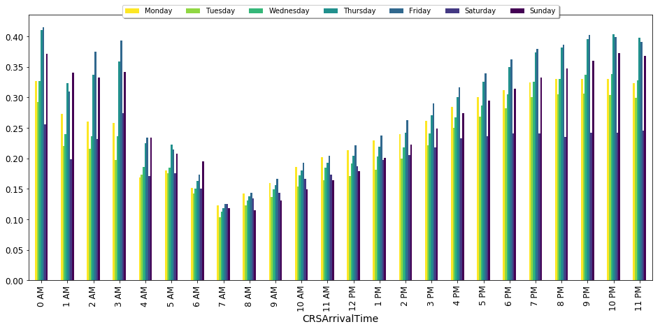

```python
# Let's plot a facetted bar chart to check the percent of delayed flights per "DayOfWeek" per "CRSArrivalTime"
df2 = pd.DataFrame(table)
ax = df2.plot.bar(figsize=[16,7], colormap='viridis_r')
ax.legend(loc='upper center', bbox_to_anchor=(0.5, 1.05), ncol=7,
          fancybox=True, shadow=True);
```

In the facetted bar chart above we can see that, in our clean dataset, on average the percentage of delayed flights per scheduled arrival hour hits its lowest at 7 AM for most days of week.

```python
# Let's get the percent of delayed flights per "CRSArrivalTime" per "DayOfWeek"
table = df_clean.groupby(['DayOfWeek', 'CRSArrivalTime'])['Delayed'].mean().unstack(fill_value=0)
table
```

| CRSArrivalTime DayOfWeek | 0 AM | 1 AM | 2 AM | 3 AM | 4 AM | 5 AM | 6 AM | 7 AM | 8 AM | 9 AM | 10 AM | 11 AM | 12 PM | 1 PM | 2 PM | 3 PM | 4 PM | 5 PM | 6 PM | 7 PM | 8 PM | 9 PM | 10 PM | 11 PM |
| --- | --- | --- | --- | --- | --- | --- | --- | --- | --- | --- | --- | --- | --- | --- | --- | --- | --- | --- | --- | --- | --- | --- | --- | --- |
| Monday | 0.326983 | 0.273333 | 0.260674 | 0.258333 | 0.168776 | 0.179957 | 0.151904 | 0.122384 | 0.142312 | 0.159238 | 0.185776 | 0.201862 | 0.213320 | 0.229327 | 0.240158 | 0.261493 | 0.284792 | 0.300708 | 0.312062 | 0.324733 | 0.329953 | 0.330791 | 0.330511 | 0.323875 |
| Tuesday | 0.292665 | 0.219917 | 0.215873 | 0.197802 | 0.173107 | 0.175156 | 0.141873 | 0.103673 | 0.123114 | 0.136195 | 0.154387 | 0.164373 | 0.171414 | 0.181452 | 0.200107 | 0.221975 | 0.250452 | 0.268184 | 0.282031 | 0.300407 | 0.305261 | 0.306626 | 0.303823 | 0.299648 |
| Wednesday | 0.326979 | 0.239621 | 0.236041 | 0.235849 | 0.185944 | 0.184738 | 0.150659 | 0.112573 | 0.130345 | 0.149310 | 0.171671 | 0.184368 | 0.192085 | 0.202729 | 0.218029 | 0.240886 | 0.267050 | 0.287049 | 0.305706 | 0.325950 | 0.330522 | 0.336751 | 0.337877 | 0.327551 |
| Thursday | 0.411126 | 0.323201 | 0.337812 | 0.358779 | 0.224704 | 0.222461 | 0.163370 | 0.117868 | 0.137532 | 0.155855 | 0.179976 | 0.192618 | 0.204271 | 0.219157 | 0.241811 | 0.270546 | 0.300723 | 0.325228 | 0.350333 | 0.373417 | 0.382348 | 0.395401 | 0.403424 | 0.398065 |
| Friday | 0.415458 | 0.309409 | 0.375235 | 0.393333 | 0.233622 | 0.215137 | 0.173073 | 0.124847 | 0.143446 | 0.166086 | 0.193167 | 0.203993 | 0.221869 | 0.236940 | 0.262488 | 0.289816 | 0.316974 | 0.339527 | 0.362653 | 0.379724 | 0.386902 | 0.402033 | 0.399646 | 0.391181 |
| Saturday | 0.255722 | 0.198741 | 0.231638 | 0.273810 | 0.171468 | 0.175629 | 0.149925 | 0.125145 | 0.134207 | 0.143458 | 0.166054 | 0.173177 | 0.186632 | 0.197618 | 0.205655 | 0.218586 | 0.233493 | 0.236491 | 0.240851 | 0.240889 | 0.234956 | 0.242346 | 0.241787 | 0.245270 |
| Sunday | 0.371546 | 0.340606 | 0.332714 | 0.342105 | 0.234146 | 0.207698 | 0.195062 | 0.118532 | 0.114681 | 0.130550 | 0.148882 | 0.164260 | 0.178523 | 0.201023 | 0.222109 | 0.249116 | 0.273868 | 0.295171 | 0.314176 | 0.332386 | 0.348020 | 0.360133 | 0.372396 | 0.368176 |

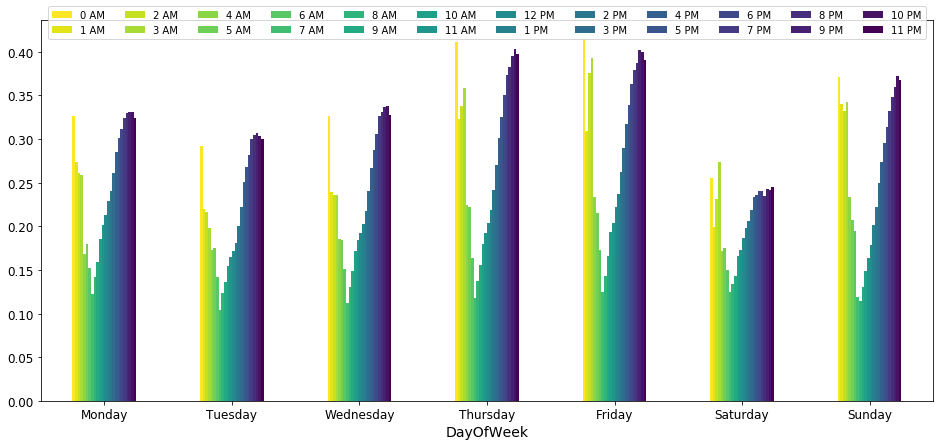

```python
# Let's plot a facetted bar chart to check the percent of delayed flights per "CRSArrivalTime" per "DayOfWeek"
df2 = pd.DataFrame(table)
ax = df2.plot.bar(figsize=[16,7], colormap='viridis_r')
ax.legend(loc='upper center', bbox_to_anchor=(0.5, 1.05), ncol=12,
          fancybox=True, shadow=False)
plt.xticks(rotation=0);
```

In the facetted bar chart above we can see that, in our clean dataset, on average the percentage of delayed flights per scheduled arrival hour hits its highest between 9 PM and 0 AM (inclusive) in most days of the week.

**#6: What is the distribution of flight operations that arrived late per hour (Schedule Arrival Time) each weekend/weekday? Is there any pattern?**

```python
# Let's first get a table of amount of flights per "CRSArrivalTime" of "Weekday_Weekend"
table = df_clean.groupby(['Weekday_Weekend', 'CRSArrivalTime']).size().unstack(fill_value=0)
table
```

| CRSArrivalTime Weekday_Weekend | 0 AM | 1 AM | 2 AM | 3 AM | 4 AM | 5 AM | 6 AM | 7 AM | 8 AM | 9 AM | 10 AM | 11 AM | 12 PM | 1 PM | 2 PM | 3 PM | 4 PM | 5 PM | 6 PM | 7 PM | 8 PM | 9 PM | 10 PM | 11 PM |
| --- | --- | --- | --- | --- | --- | --- | --- | --- | --- | --- | --- | --- | --- | --- | --- | --- | --- | --- | --- | --- | --- | --- | --- | --- |
| Weekday | 35824 | 7348 | 2208 | 1196 | 3611 | 27567 | 55153 | 191140 | 279895 | 315633 | 354798 | 324003 | 344969 | 308571 | 333294 | 321633 | 364006 | 336760 | 350410 | 316533 | 354105 | 292601 | 260386 | 160845 |
| Weekend | 12893 | 2762 | 892 | 556 | 1549 | 10492 | 18269 | 57360 | 86507 | 108530 | 128344 | 124868 | 129508 | 117901 | 126614 | 123952 | 137972 | 125996 | 130538 | 117425 | 124036 | 100685 | 88204 | 56917 |

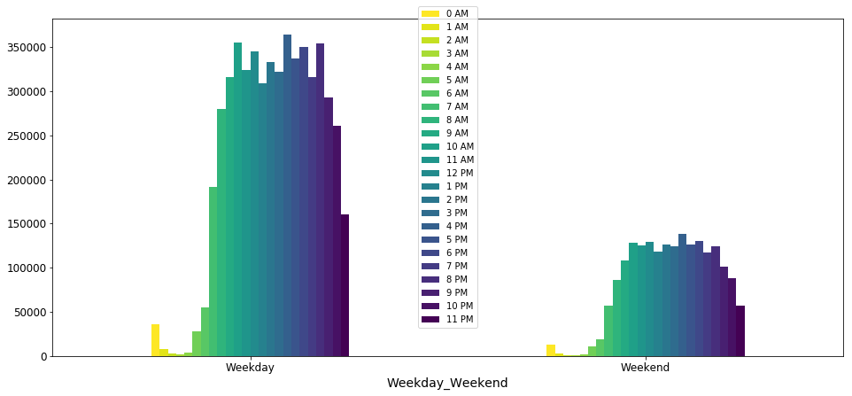

```python
# Let's plot a facetted bar chart to check the amount of flights per "CRSArrivalTime" of "Weekday_Weekend"
df2 = pd.DataFrame(table)
ax = df2.plot.bar(figsize=[16,7], colormap='viridis_r')
ax.legend(loc='upper center', bbox_to_anchor=(0.5, 1.05),
          fancybox=True, shadow=False)
plt.xticks(rotation=0);
```

In the above facetted bar chart we can see that, in our clean dataset, there is a clear flight reduction between 0 AM and 6 AM (inclusive) during both weekdays and weekends. With the graph we also re-confirm the univariate insight that the amount of flights on weekdays is greater than on weekends.

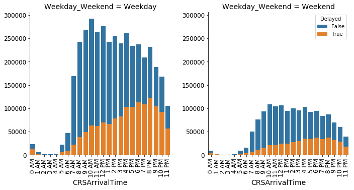

```python
# Let's plot the amount of flights that arrived late and not arrived late each "CRSArrivalTime" of "Weekday_Weekend"
g = sns.FacetGrid(data = df_clean, col = 'Weekday_Weekend', hue = 'Delayed', size = 5)
g.map(sns.countplot, "CRSArrivalTime", order=df_clean.CRSArrivalTime.cat.categories)
plt.legend(title = 'Delayed')
g.set_xticklabels(rotation=90);
```

```python
# Let's get our table of amount of delayed flights per "CRSArrivalTime" of "Weekday_Weekend"
table = df_clean[df_clean['Delayed']==True].groupby(['Weekday_Weekend', 'CRSArrivalTime']).size().unstack(fill_value=0)
table
```

| CRSArrivalTime Weekday_Weekend | 0 AM | 1 AM | 2 AM | 3 AM | 4 AM | 5 AM | 6 AM | 7 AM | 8 AM | 9 AM | 10 AM | 11 AM | 12 PM | 1 PM | 2 PM | 3 PM | 4 PM | 5 PM | 6 PM | 7 PM | 8 PM | 9 PM | 10 PM | 11 PM |
| --- | --- | --- | --- | --- | --- | --- | --- | --- | --- | --- | --- | --- | --- | --- | --- | --- | --- | --- | --- | --- | --- | --- | --- | --- |
| Weekday | 12744 | 2038 | 653 | 360 | 719 | 5399 | 8623 | 22231 | 37894 | 48426 | 62850 | 61422 | 69297 | 66091 | 77574 | 82702 | 103420 | 102445 | 113042 | 107890 | 122877 | 103732 | 92523 | 56056 |
| Weekend | 4173 | 783 | 261 | 173 | 317 | 2011 | 3143 | 6999 | 10812 | 14877 | 20211 | 21066 | 23629 | 23505 | 27120 | 29037 | 35117 | 33724 | 36546 | 34082 | 37147 | 31355 | 28211 | 18006 |

```python
# Let's get the average amount of delayed flights per "CRSArrivalTime" per "Weekday_Weekend"
mean = table.mean().mean()
mean
```

```
37569.020833333336
```

```python
# Let's get the minimum amount of delayed flights per "CRSArrivalTime" per "Weekday_Weekend"
minimum = table.min().min()
minimum
```

```
173
```

```python
# Let's get the difference between the minimum and the average amount
( minimum - mean ) / mean * 100
```

```
-99.539514216334041
```

In the facetted bar chart above we can see that, in our clean dataset, the amount of delayed flights per Scheduled Arrival Time (hour) is always lower than the amount of not delayed flights per Scheduled Arrival Time (hour) in both weekdays and weekends.

We also see that the amount of delayed flights is the lowest between 1 AM - 4 AM (inclusive) in both weekdays and weekends, up to 100% lower than the mean. This is no surprise because the amount of flights is also low during those hours during both weekdays and weekends.

Finally, we see a general lower amount of delayed flights in weekends than on weekdays. This is no surprise because the amount of flights is also low on weekends compared to weekdays.

However, as the bivariate analysis stated, in percent terms, weekdays and weekends both have a similar percent of annual delayed flights. Let's check that out in a facetted bar chart of percents of delayed flights per "CRSArrivalTime" per "Weekday_Weekend".

```python
# Let's get the percent of delayed flights per "CRSArrivalTime" per "Weekday_Weekend"
table = df_clean.groupby(['CRSArrivalTime', 'Weekday_Weekend'])['Delayed'].mean().unstack(fill_value=0)
table
```

| Weekday_Weekend CRSArrivalTime | Weekday | Weekend |
| --- | --- | --- |
| 0 AM | 0.355739 | 0.323664 |
| 1 AM | 0.277354 | 0.283490 |
| 2 AM | 0.295743 | 0.292601 |
| 3 AM | 0.301003 | 0.311151 |
| 4 AM | 0.199114 | 0.204648 |
| 5 AM | 0.195850 | 0.191670 |
| 6 AM | 0.156347 | 0.172040 |
| 7 AM | 0.116307 | 0.122019 |
| 8 AM | 0.135386 | 0.124984 |
| 9 AM | 0.153425 | 0.137077 |
| 10 AM | 0.177143 | 0.157475 |
| 11 AM | 0.189572 | 0.168706 |
| 12 PM | 0.200879 | 0.182452 |
| 1 PM | 0.214184 | 0.199362 |
| 2 PM | 0.232749 | 0.214194 |
| 3 PM | 0.257132 | 0.234260 |
| 4 PM | 0.284116 | 0.254523 |
| 5 PM | 0.304208 | 0.267659 |
| 6 PM | 0.322599 | 0.279964 |
| 7 PM | 0.340849 | 0.290245 |
| 8 PM | 0.347007 | 0.299486 |
| 9 PM | 0.354517 | 0.311417 |
| 10 PM | 0.355330 | 0.319838 |
| 11 PM | 0.348509 | 0.316355 |

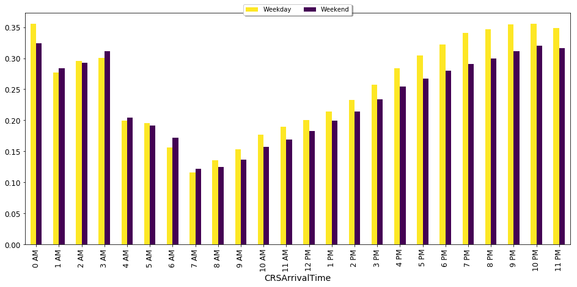

```python
# Let's plot a facetted bar chart to check the percent of delayed flights per "CRSArrivalTime" of "Weekday_Weekend"
df2 = pd.DataFrame(table)
ax = df2.plot.bar(figsize=[16,7], colormap='viridis_r')
ax.legend(loc='upper center', bbox_to_anchor=(0.5, 1.05), ncol=2,
          fancybox=True, shadow=True);
```

Both weekdays and weekends have their lowest percentage of delayed flights at 7 AM, and their highest at 0 AM.

**#7: Does the percentage of flights operation that were late for the Top 4 Airlines (based on their percent of late operations) vary per Top 10 Airports (based on amount of flights operation / arrivals)?**

```python
# Let's get the Top 4 Airlines (based on the lowest percent of late operations)
top4_airlines = df_clean.groupby('UniqueCarrier')['Delayed'].mean().sort_values().head(4).index.values
top4_airlines
```

```
array(['HA', 'AQ', 'WN', '9E'], dtype=object)
```

```python
# Let's get the Top 10 Airports (based on the highest amount of flights operation / arrivals)
top10_airports = df_clean['Dest'].value_counts().head(10).index.values
top10_airports
```

```
array(['ATL', 'ORD', 'DFW', 'DEN', 'LAX', 'PHX', 'IAH', 'LAS', 'DTW', 'MSP'], dtype=object)
```

```python
# Let's get our filtered data based on that Top 4 Airlines and Top 10 Airports
filtered_data = df_clean[df_clean.UniqueCarrier.isin(top4_airlines)]
filtered_data = filtered_data[filtered_data.Dest.isin(top10_airports)]
filtered_data.sample(10)
```

|  | Month | DayOfMonth | DayOfWeek | UniqueCarrier | FlightNum | CRSElapsedTime | Origin | Dest | Distance | CRSArrivalTime | Delayed | Route | Weekday_Weekend |
| --- | --- | --- | --- | --- | --- | --- | --- | --- | --- | --- | --- | --- | --- |
| 459721 | 1 | 10 | Wednesday | 9E | 5615 | 126.0 | XNA | MSP | 596 | 10 AM | False | XNA - MSP | Weekday |
| 6136118 | 11 | 18 | Sunday | WN | 940 | 85.0 | BUR | PHX | 369 | 12 PM | True | BUR - PHX | Weekend |
| 4090419 | 7 | 19 | Thursday | 9E | 5816 | 60.0 | FWA | DTW | 128 | 7 AM | True | FWA - DTW | Weekday |
| 5542019 | 10 | 26 | Friday | WN | 1935 | 60.0 | LAX | LAS | 236 | 7 PM | True | LAX - LAS | Weekday |
| 13155 | 1 | 6 | Saturday | WN | 1331 | 155.0 | AUS | PHX | 872 | 6 PM | False | AUS - PHX | Weekend |
| 1012060 | 2 | 13 | Tuesday | 9E | 2959 | 105.0 | CID | DTW | 431 | 9 AM | True | CID - DTW | Weekday |
| 2852486 | 5 | 21 | Monday | 9E | 5872 | 111.0 | DLH | DTW | 541 | 9 AM | True | DLH - DTW | Weekday |
| 3692446 | 7 | 30 | Monday | WN | 1113 | 65.0 | LAX | LAS | 236 | 6 PM | False | LAX - LAS | Weekday |
| 4902792 | 9 | 12 | Wednesday | WN | 820 | 75.0 | LAX | PHX | 370 | 9 PM | False | LAX - PHX | Weekday |
| 7136624 | 12 | 15 | Saturday | 9E | 5824 | 130.0 | SGF | DTW | 635 | 3 PM | False | SGF - DTW | Weekend |

```python
# Let's get the percent of delayed flights per Airline per Airport from that filtered data
table = filtered_data.groupby(['UniqueCarrier', 'Dest'])['Delayed'].mean().unstack(fill_value=0)
table
```

| Dest UniqueCarrier | ATL | DEN | DFW | DTW | IAH | LAS | LAX | MSP | PHX |
| --- | --- | --- | --- | --- | --- | --- | --- | --- | --- |
| 9E | 0.325843 | 0.242991 | 0.230228 | 0.207482 | 0.237308 | 0.000000 | 0.000000 | 0.22106 | 0.000000 |
| AQ | 0.000000 | 0.000000 | 0.000000 | 0.000000 | 0.000000 | 0.116418 | 0.000000 | 0.00000 | 0.000000 |
| HA | 0.000000 | 0.000000 | 0.000000 | 0.000000 | 0.000000 | 0.249651 | 0.261186 | 0.00000 | 0.293151 |
| WN | 0.000000 | 0.211783 | 0.000000 | 0.204629 | 0.000000 | 0.179878 | 0.192415 | 0.00000 | 0.177102 |

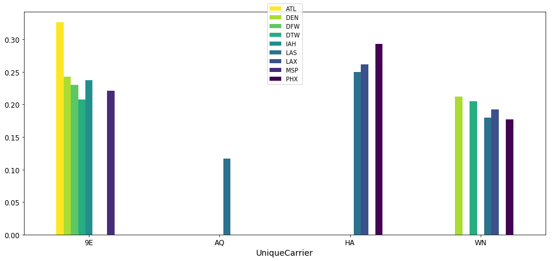

```python
# Let's plot a facetted bar chart to check the percent of delayed flights per Airline per Airport
df2 = pd.DataFrame(table)
ax = df2.plot.bar(figsize=[16,7], colormap='viridis_r')
ax.legend(loc='upper center', bbox_to_anchor=(0.5, 1.05),
          fancybox=True, shadow=False)
plt.xticks(rotation=0);
```

In the facetted bar chart above we can see how the percent of delayed flights per Top 10 Airports (based on amount of flights operation / arrivals) varies among all the Top 4 Airlines (based on their percent of late operations). We do not see a clear pattern in the percentages.

We noticed that none of the Top 4 Carriers arrive to all Top 10 Airports. From the bivariate analysis we know that some of these airlines, like Hawaiian Airlines (HA) and Aloha Airlines (AQ), have few operations, so it is not surprising they don't arrive to all the airports. However, Southwest Airlines (WN) having the highest amount of annual operations does not arrive to all the Top 10 Airports, either.

**#8: What is the distribution of flights on weekday and weekend days each month? Is there any pattern?**

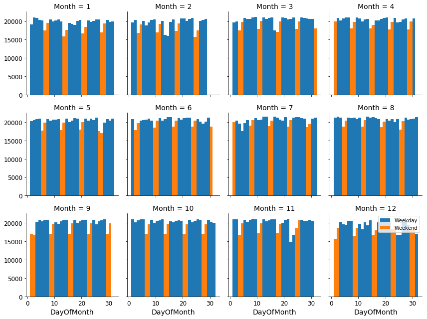

```python
# Let's plot a histogram of amount of flights per day facetted by month and encoded by weekday/weekend
bins = np.arange(1,31+2,1)
g = sns.FacetGrid(data = df_clean, col = 'Month', col_wrap = 4, hue = 'Weekday_Weekend')
g.map(plt.hist, "DayOfMonth", bins=bins)
plt.legend();
```

In the facetted histogram above we can see that, in our clean dataset, the amount of flights per day of each month is mostly lower when it's a weekend than when it's a weekday. This could be because there are more business flights happening during weekdays than on weekends, or maybe weekdays' price is lower hence the increment of flights. However, since there is no information to confirm any of these hypotheses, further analsys should be made.

### Let's talk about some of the relationships we observed in this part of the investigation.

- The pattern observed in the bivariate analysis (the amount of delayed flights is always lower than the amount of not delayed flights throughout the months) mostly remains even when analyzing it on a multivariate level by scheduled arrival hour, day of month, day of week or weekday/weekend.
- The amount of flights per month is directly related to the number of delayed flights per month when analyzing it by day of week, scheduled arrival hour or weekday/weekend. We didn’t see this pattern when analyzing the data per day of month per month, though.
- The percent of delayed flights per month is directly related to the amount of delayed flights per month when analyzing it by day of month or day of week. We didn’t see this pattern repeating when analyzing the data per scheduled arrival hour per month or weekday/weekend, though.

### Were there any interesting or surprising interactions between features?

- The pattern of decreased flights between 0 AM and 6 AM (inclusive) from the bivariate analysis remains when analyzing it on a multivariate level by days of week and weekdays/weekends.
- The amount of delayed flights is always lower than the amount of not delayed flights throughout the scheduled arrival hours when analyzing it by days of week or weekday/weekend.

## Conclusions

**Main insights**  
For our clean dataset (2007 domestic flights in United States reported by 21 carriers), we can conclude the following:

- 24.8% of flights were delayed.
- 73.4% of flights happened during weekdays.
- Most of the flights (70% or more) were on time each month.
- Most of the flights (70% or more) were on time each day of the week.
- There is a clear flight reduction between 0 AM and 6 AM (inclusive), in annual terms.
- There is a clear flight reduction between 0 AM and 6 AM (inclusive) throughout the months.
- There is a clear flight reduction between 0 AM and 6 AM (inclusive) during both weekdays and weekends.
- The preferred hours to flight are between 9 AM - 8 PM (inclusive).
- The majority of Flights (between 25% and 75% percentile) had a Distance between airports between 320 and 948 miles.
- The majority of Flights (between 25% and 75% percentile) had a Scheduled Elapsed Time between 78 and 157 minutes.
- Southwest Airlines (WN) is the carrier who had the highest annual number of flights (even 2 times higher than the average amount of flights per carrier).
- Atlanta's Hartsfield-Jackson (ATL) is the airport who had the highest annual number of flights as origin and destination (even 15 times higher than the average amount of flights per origin or destination).
- "16" is the Flight Number who had the highest annual number of fligths (even 4 times higher than the average amount of flights per flight number).
- KAHULUI HI (OGG) - HONOLULU HI (HNL) is the route who had the highest annual number of flights (even 15 times higher than the average amount of flights per route). The second route involves also those two airport but with the inverse order.
- The majority of months (between 25% and 75% percentile) had a Percentage of Flight Delay between 21 and 28.7%.
- The majority of days of the week (between 25% and 75% percentile) had a Percentage of Flight Delay between 23.2 and 26.3%.
- The majority of Schedule Arrival hours (between 25% and 75% percentile) had a Percentage of Flight Delay between 19.2% and 31.5%.
- The majority of Origin Airports (between 25% and 75% percentile) had between 8.7% and 36.2% of their flights arriving late to their destination.
- The majority of Destination Airports (between 25% and 75% percentile) had a delayed in their arrival operations between 22.4% and 29.3%.
- The majority of flight numbers (between 25% and 75% percentile) had a percent of late operations between 20.2% and 30.4%.
- The majority of Routes (between 25% and 75% percentile) had a percent of late operations between 18% and 30.4%.
- The majority of Delayed Flights (between 25% and 75%) had a Distance between 334 and 980 miles from origin to destination.
- The majority of Delayed Flights (between 25% and 75%) had a Scheduled Elapsed Time between 80 and 160 minutes.
- Weekdays and weekends both have a similar percent of delayed flights. Weekdays have a slight higher percentage than the average (5% above).
- Hawaiian Airlines (HA) is the Carrier who had the lowest percent of late operations: 6.31%, which is 73% lower than the average percent of delay per carrier.
- Atlantic Southeast Airlines (EV) is the Carrier who had the highest percent of late operations: 33.02%, which is 39% higher than the average percent of delay per carrier.
- Most of the flights (65% or more) were on time each hour (Schedule Arrival Time).
- There was a spike in the percent of delays per hour between 9 PM and 0 AM (inclusive), and a notable reduction in the percent of delays at 7 AM. The highest value (at 10 PM and 0 AM) was 39% above the mean and the lowest value (7 AM) was 53% below the mean.
- Moore County Airport (SOP) is the airport with the worst percent of late arrival operations: 47.85%, 85% higher than the Average percent of late operations by Destination Airport.
- The average arrival delay per origin airport is 22.98%.
- The average arrival delay per destination airport is 25.84%.
- The distribution of Distance is pretty similar whether a flight was delayed or not.
- The distribution of Scheduled Elapsed Time is pretty similar whether a flight was delayed or not.
- Saturday tends to have the lowest amount of flights per day of week in most of the months, with a mean of 76,302 flights per month.
- The amount of flights per day of each month is mostly lower when it's a weekend than when it's a weekday.
- On average, the percentage of delayed flights per day hits its lowest on September.
- On average, 4,940 flights arrived late per day of each month, which is 67% lower than the average amount of flights that didn't arrive late per day of each month (14,991 flights).
- On average, the percentage of delayed flights per day of week hits its lowest on Saturday through most of the months.
- On average, the percentage of delayed flights per scheduled arrival hour hits its lowest at 7 AM for most days of week.
- On average, the percentage of delayed flights per scheduled arrival hour hits its highest between 9 PM and 0 AM (inclusive) in most days of the week.
- On average, the percentage of delayed flights per scheduled arrival hour hits its lowest at 7 AM through most of the months.
- On average, the percentage of delayed flights is similar for both weekdays and weekends. However, the percentage of delayed flights is higher on weekdays in most of the months.
- Out of the delayed flights per month, on average 76% of them happened on weekdays.
- The pattern of decreased flights between 0 AM and 6 AM (inclusive) from the bivariate analysis remains when analyzing it on a multivariate level by days of week and weekdays/weekends.
- The amount of delayed flights is always lower than the amount of not delayed flights throughout the scheduled arrival hours when analyzing it by days of week or weekday/weekend.
- The amount of delayed flights on Saturday's is the lowest in most of the months, with a mean of 15,531 delayed flights per month.
- The amount of delayed flights is the lowest between 1 AM - 4 AM (inclusive) every month, being 44 delayed flights the lowest average per hour.
- The amount of delayed flights is always lower than the amount of not delayed flights throughout the months. This pattern mostly remains even when analyzing it on a multivariate level by scheduled arrival hour, day of month, day of week or weekday/weekend.

**Other insights**

Limitations of this Project:

- The dataset only included the domestic operations of 21 airlines of United States, so the scope of the analysis is limited by that.
- Due to the heavy amount of data per year, we decided to only analyze 2007 flight data for this project.
- Since there were missing values in "CRSElapsedTime" and "ArrDelay" columns, that we could not retrieve, those rows were dropped. As a result, 2.39% of rows were removed from the original dataset.

Other considerations:

- In the 2007 dataset, there is no information about the airplane model, so the analysis will not include it.
- Even though the "UniqueCarrier" codes are not explicit enough, we will only fix the names for explanatory graphs since these codes are recognized by IATA.
- According to [U.S.DOT Report of December 2007](https://www.transportation.gov/sites/dot.dev/files/docs/200802ATCR.pdf), data of the merged operations of US Airways (US) and America West Airlines (HP) are combined, and appear only as "US" in this dataset.
- As of december 2007, the rule required carriers to report on operations to and from the 32 U.S. airports that accounted for at least one percent of the nation's total domestic scheduled-service passenger enplanements. However, all reporting airlines voluntarily provided data for their entire domestic systems, and that information is included in the dataset. The analysis will be based on the total of airports reported.
- All times are local. A 10:50 a.m. departure from Atlanta is 10:50 a.m. Atlanta time; if that flight arrived in Dallas at 11:45 a.m., that is 11:45 a.m. Dallas time.
- "On time" means an arrival less than 15 minutes after scheduled arrival time; cancelled and diverted flights are not considered on-time arrivals.
- According to [U.S.DOT Report of December 2007](https://www.transportation.gov/sites/dot.dev/files/docs/200802ATCR.pdf), the Flight Status can be "On Time", "Delayed", "Cancelled" or "Diverted".
- We decided to drop "DepTime", "CRSDepTime", "ArrTime", "DepDelay", "TailNum", "ActualElapsedTime", "AirTime", "TaxiIn", "TaxiOut", "Cancelled", "CancellationCode", "Diverted", "CarrierDelay", "WeatherDelay", "NASDelay", "SecurityDelay" and "LateAircraftDelay" columns because those are not factors that can generate a flight delay, but information post-delay or post-cancellation or post-diversion.
- To ease the analysis, the "CRSArrivalTime" column was created considering intervals of 59 minutes, but the label only reflected the hour. P.E: We used the category label of "0 AM" for the "00:00-00:59" range.

## Appendix

NOTE: The Department of Transportation has screened the reporting carriers' data for completeness and verified all arithmetic data elements computed by the carriers (e.g., length of delay). Individual flight operations records with incorrect calculations, erroneous city-pairs, or missing data elements were rejected and excluded from the dataset; such rejected records accounted for less than 0.01% of the flight operations records submitted. Any errors in the dataset with respect to basic flight data -- non-computed data elements such as flight numbers, scheduled and actual arrival/departure times, days of operation -- are the responsibility of the reporting carrier.

*Airports Covered by the Rule (14 CFR PART 234), as of December 2007*

- Atlanta: Hartsfield-Jackson ATL
- Balt/Wash: Int’l Thurgood Marshall BWI
- Boston: Logan International BOS
- Charlotte: Douglas CLT
- Chicago: Midway MDW
- Chicago: O'Hare ORD
- Cincinnati: Greater Cincinnati CVG
- Dallas-Fort Worth: International DFW
- Denver: International DEN
- Detroit: Metro Wayne County DTW
- Ft. Lauderdale: International FLL
- Houston: George Bush IAH
- Las Vegas: McCarran International LAS
- Los Angeles: International LAX
- Miami: International MIA
- Minneapolis-St. Paul: International MSP
- Newark: Liberty International EWR
- New York: JFK International JFK
- New York: LaGuardia LGA
- Oakland : International OAK
- Orlando: International MCO
- Philadelphia: International PHL
- Phoenix: Sky Harbor International PHX
- Portland: International PDX
- Salt Lake City: International SLC
- San Diego: Lindbergh Field SAN
- San Francisco: International SFO
- Seattle-Tacoma: International SEA
- ST. Louis : Lambert International STL
- Tampa: Tampa International TPA
- Washington: Reagan National DCA
- Washington: Dulles IAD

*Air Carriers Required to Report Data to DOT and to CRS Vendors, as of December 2007*

- FL AirTran Airways
- AS Alaska Airlines
- HP America West Airlines*
- AA American Airlines
- MQ American Eagle Airlines
- EV Atlantic Southeast Airlines
- OH Comair
- CO Continental Airlines
- DL Delta Air Lines
- XE ExpressJet Airlines
- F9 Frontier Airlines
- B6 JetBlue Airways
- YV Mesa Airlines
- NW Northwest Airlines
- 9E Pinnacle Airlines
- OO SkyWest Airlines
- WN Southwest Airlines
- UA United Airlines
- US US Airways*

*Air Carriers Voluntarily Reporting Data to DOT and to CRS Vendors, as of December 2007*

- AQ Aloha Airlines (eff. 04/06)
- HA Hawaiian Airlines (eff. 01/07)

* Data of the merged operations of US Airways (US) and America West Airlines (HP) are combined, and appear only as US in this dataset.

Data References:

- Flights Dataset Source: https://dataverse.harvard.edu/dataset.xhtml?persistentId=doi:10.7910/DVN/HG7NV7
- Airline On-Time Performance and Causes of Flight Delays: https://www.bts.dot.gov/explore-topics-and-geography/topics/airline-time-performance-and-causes-flight-delays
- Defining and Measuring Aircraft Delay and Airport Capacity Thresholds: https://www.nap.edu/download/22428
- Air Travel Consumer Report for December 2007: https://www.transportation.gov/airconsumer/air-travel-consumer-reports-2008
- U.S.DOT Data Information : https://www.transtats.bts.gov
- Variable descriptions: http://stat-computing.org/dataexpo/2009/the-data.html

Other References:

- Display all info in pandas: https://stackoverflow.com/questions/43427564/display-all-informations-with-data-info-in-python
- Display all columns in pandas: https://stackoverflow.com/questions/11707586/how-do-i-expand-the-output-display-to-see-more-columns-of-a-pandas-dataframe
- Change numbers to day names: https://stackoverflow.com/questions/29096381/num-day-to-name-day-with-pandas
- Combine two columns of text: https://stackoverflow.com/questions/19377969/combine-two-columns-of-text-in-dataframe-in-pandas-python
- Format axis labels for thousand values: https://stackoverflow.com/questions/51734218/formatting-y-axis-matplotlib-with-thousands-separator-and-font-size
- Text labels in Stacked Bar Chart: https://stackoverflow.com/questions/41296313/stacked-bar-chart-with-centered-labels
- Groupby and Value Counts: https://stackoverflow.com/questions/39132742/groupby-value-counts-on-the-dataframe-pandas
- Pandas visualization: http://pandas-docs.github.io/pandas-docs-travis/user_guide/visualization.html
- Groupby and Percentage: https://stackoverflow.com/questions/23377108/pandas-percentage-of-total-with-groupby/23377155
- Legend out of the box: https://stackoverflow.com/questions/4700614/how-to-put-the-legend-out-of-the-plot
- Use a list of values to select rows: https://stackoverflow.com/questions/12096252/use-a-list-of-values-to-select-rows-from-a-pandas-dataframe
- Wrangling and Analyzing Twitter Data (own work): https://github.com/andrea-villanca/Udacity-DAND/tree/master/Wrangling-And-Analyzing-Twitter-Data
- Analyzing a movie dataset (own work): https://github.com/andrea-villanca/Udacity-DAND/tree/master/Analyzing-a-movie-dataset